# Описание проекта

HR-аналитики компании «Работа с заботой» помогают бизнесу оптимизировать управление персоналом: бизнес предоставляет данные, а аналитики предлагают, как избежать финансовых потерь и оттока сотрудников. В этом HR- аналитикам пригодится машинное обучение, с помощью которого получится быстрее и точнее отвечать на вопросы бизнеса. Компания предоставила данные с характеристиками сотрудников компании. Среди них — уровень удовлетворённости сотрудника работой в компании. Эту информацию получили из форм обратной связи: сотрудники заполняют тест-опросник, и по его результатам рассчитывается доля их удовлетворённости от 0 до 1, где 0 — совершенно неудовлетворён, 1 — полностью удовлетворён.

Собирать данные такими опросниками не так легко: компания большая, и всех сотрудников надо сначала оповестить об опросе, а затем проследить, что все его прошли.

**Задачи исследования**:

- построить модель, которая сможет предсказать уровень удовлетворённости сотрудника на основе данных заказчика;
- построить модель, которая сможет на основе данных заказчика предсказать то, что сотрудник уволится из компании.

Почему бизнесу это важно: удовлетворённость работой напрямую влияет на отток сотрудников. А предсказание оттока — одна из важнейших задач HR-аналитиков. Внезапные увольнения несут в себе риски для компании, особенно если уходит важный сотрудник.

**Этапы исследования для каждой задачи:**

- исследовать входные и целевой признаки;
- провести корреляционный анализ;
- построить модель и оценить её качество с помощью выбранной метрики.

**Ход исследования**

В начале подготовим данные: проверим датасеты на наличие полных и неявных дубликатов, подсчитаем пропуски в данных и проверим соответствие значений в столбцах их типам.

Далее проведём исследовательский анализ данных для каждой задачи. Построим графики с распределением и числовым размахом для каждой переменной, попробуем выявить аномалии, выбросы и закономерности, а также рассмотрим распределение сотрудников по категориальным признакам. Перед построением модели необходимо будет провести корреляционный анализ: построить матрицы корреляций для целевого и входных признаков, оценить наличие мультиколлинеарности.

Потом приступим к построению пайплайна. Для кодирования категориальных признаков используем как минимум два кодировщика, для масштабирования количественных — как минимум два скейлера.

Для первой задачи обучим две модели: LinearRegression() и DecisionTreeRegressor(), подберём для них гиперпараметры с помощью RandomizedSearchCV. В результате выберем лучшую модель, используя пользовательскую метрику качества SMAPE. Критерий успеха: SMAPE ≤ 15 на тестовой выборке.

Для второй задачи Обучим четыре модели: KNeighborsClassifier(), DecisionTreeClassifier(), LogisticRegression() и SVC(), подберём для них гиперпараметры с помощью RandomizedSearchCV. В результате выберем лучшую модель, используя метрику качества ROC-AUC. Критерий успеха: ROC-AUC ≥ 0.91 на тестовой выборке.

## Импорт библиотек, модулей

```python
import pandas as pd

import seaborn as sns
import matplotlib.pyplot as plt
import matplotlib
from matplotlib.ticker import (MultipleLocator, FormatStrFormatter, AutoMinorLocator)
# импорт библиотек pandas, seaborn, matplotlib.pyplot

import numpy as np
from scipy import stats as st
from scipy.stats import shapiro
from scipy.stats import anderson
import phik

import shap

from statsmodels.stats.outliers_influence import variance_inflation_factor
import statsmodels.api as sm
# импорт библиотек numpy, scipy, statsmodels

from sklearn.model_selection import train_test_split

from sklearn.pipeline import Pipeline
# загружаем класс pipeline

from sklearn.preprocessing import OneHotEncoder, OrdinalEncoder, StandardScaler, MinMaxScaler, RobustScaler
from sklearn.compose import ColumnTransformer
# загружаем классы для подготовки данных

from sklearn.impute import SimpleImputer
# загружаем класс для работы с пропусками

from sklearn.model_selection import RandomizedSearchCV, GridSearchCV
from optuna.integration import OptunaSearchCV
from optuna import distributions
# импортируем класс RandomizedSearchCV и OptunaSearchCV

from sklearn.linear_model import LogisticRegression
from sklearn.neighbors import KNeighborsClassifier
from sklearn.tree import DecisionTreeClassifier, DecisionTreeRegressor
from sklearn.svm import SVC
from sklearn.linear_model import LinearRegression
# загружаем нужные модели

from sklearn.metrics import roc_auc_score, f1_score, make_scorer
# загружаем функцию для работы с метриками

%config InlineBackend.figure_format='jpg'
import warnings
warnings.filterwarnings('ignore')
```

```python
RANDOM_STATE = 42
```

## Загрузка и обзор данных

```python
try:
    test_features_df = pd.read_csv('/datasets/test_features.csv')
    train_satisfaction_df = pd.read_csv('/datasets/train_job_satisfaction_rate.csv')
    test_target_satisfaction_df = pd.read_csv('/datasets/test_target_job_satisfaction_rate.csv')
    train_quit_df = pd.read_csv('/datasets/train_quit.csv')
    test_target_quit_df = pd.read_csv('/datasets/test_target_quit.csv')
except:
    test_features_df = pd.read_csv('/Users/galina/Desktop/Удовлетворённость_сотрудников_данные/test_features.csv')
    train_satisfaction_df = pd.read_csv('/Users/galina/Desktop/Удовлетворённость_сотрудников_данные/train_job_satisfaction_rate.csv')
    test_target_satisfaction_df = pd.read_csv('/Users/galina/Desktop/Удовлетворённость_сотрудников_данные/test_target_job_satisfaction_rate.csv')
    train_quit_df = pd.read_csv('/Users/galina/Desktop/Удовлетворённость_сотрудников_данные/train_quit.csv')
    test_target_quit_df = pd.read_csv('/Users/galina/Desktop/Удовлетворённость_сотрудников_данные/test_target_quit.csv')
# чтение файлов с данными
```

```python
def get_df_info(df):
    display(df.head(10))
    display(df.info())
    display(df.describe(include='all'))
    display(df.columns)
# создание функции для вывода характеристик датафрейма
```

```python
df_dict = {'test_features_df': test_features_df,
           'train_satisfaction_df': train_satisfaction_df,
           'test_target_satisfaction_df': test_target_satisfaction_df,
           'train_quit_df': train_quit_df,
           'test_target_quit_df': test_target_quit_df}
# создание словаря с датафреймами
```

```python
for name, value in df_dict.items():
    print('')
    print(f'Характеристики датафрейма: {name} \n')
    get_df_info(value)
# вывод характеристик для датафреймов с помощью цикла
```

```
Характеристики датафрейма: test_features_df
```

|  | id | dept | level | workload | employment_years | last_year_promo | last_year_violations | supervisor_evaluation | salary |
| --- | --- | --- | --- | --- | --- | --- | --- | --- | --- |
| 0 | 485046 | marketing | junior | medium | 2 | no | no | 5 | 28800 |
| 1 | 686555 | hr | junior | medium | 1 | no | no | 4 | 30000 |
| 2 | 467458 | sales | middle | low | 5 | no | no | 4 | 19200 |
| 3 | 418655 | sales | middle | low | 6 | no | no | 4 | 19200 |
| 4 | 789145 | hr | middle | medium | 5 | no | no | 5 | 40800 |
| 5 | 429973 | purchasing | middle | medium | 6 | no | no | 3 | 42000 |
| 6 | 850699 | technology | junior | medium | 3 | no | no | 3 | 26400 |
| 7 | 500791 | sales | middle | high | 9 | no | no | 4 | 49200 |
| 8 | 767867 | marketing | middle | high | 3 | no | yes | 4 | 62400 |
| 9 | 937235 | sales | junior | medium | 1 | no | yes | 3 | 26400 |

```
<class 'pandas.core.frame.DataFrame'>
RangeIndex: 2000 entries, 0 to 1999
Data columns (total 9 columns):
 #   Column                 Non-Null Count  Dtype
---  ------                 --------------  -----
 0   id                     2000 non-null   int64
 1   dept                   1998 non-null   object
 2   level                  1999 non-null   object
 3   workload               2000 non-null   object
 4   employment_years       2000 non-null   int64
 5   last_year_promo        2000 non-null   object
 6   last_year_violations   2000 non-null   object
 7   supervisor_evaluation  2000 non-null   int64
 8   salary                 2000 non-null   int64
dtypes: int64(4), object(5)
memory usage: 140.8+ KB
```

```
None
```

|  | id | dept | level | workload | employment_years | last_year_promo | last_year_violations | supervisor_evaluation | salary |
| --- | --- | --- | --- | --- | --- | --- | --- | --- | --- |
| count | 2000.000000 | 1998 | 1999 | 2000 | 2000.000000 | 2000 | 2000 | 2000.000000 | 2000.000000 |
| unique | NaN | 6 | 3 | 4 | NaN | 2 | 2 | NaN | NaN |
| top | NaN | sales | junior | medium | NaN | no | no | NaN | NaN |
| freq | NaN | 763 | 974 | 1043 | NaN | 1937 | 1738 | NaN | NaN |
| mean | 552765.213500 | NaN | NaN | NaN | 3.666500 | NaN | NaN | 3.526500 | 34066.800000 |
| std | 253851.326129 | NaN | NaN | NaN | 2.537222 | NaN | NaN | 0.996892 | 15398.436729 |
| min | 100298.000000 | NaN | NaN | NaN | 1.000000 | NaN | NaN | 1.000000 | 12000.000000 |
| 25% | 339052.000000 | NaN | NaN | NaN | 1.000000 | NaN | NaN | 3.000000 | 22800.000000 |
| 50% | 550793.000000 | NaN | NaN | NaN | 3.000000 | NaN | NaN | 4.000000 | 30000.000000 |
| 75% | 765763.750000 | NaN | NaN | NaN | 6.000000 | NaN | NaN | 4.000000 | 43200.000000 |
| max | 999029.000000 | NaN | NaN | NaN | 10.000000 | NaN | NaN | 5.000000 | 96000.000000 |

```
Index(['id', 'dept', 'level', 'workload', 'employment_years',
       'last_year_promo', 'last_year_violations', 'supervisor_evaluation',
       'salary'],
      dtype='object')
```

```
Характеристики датафрейма: train_satisfaction_df
```

|  | id | dept | level | workload | employment_years | last_year_promo | last_year_violations | supervisor_evaluation | salary | job_satisfaction_rate |
| --- | --- | --- | --- | --- | --- | --- | --- | --- | --- | --- |
| 0 | 155278 | sales | junior | medium | 2 | no | no | 1 | 24000 | 0.58 |
| 1 | 653870 | hr | junior | high | 2 | no | no | 5 | 38400 | 0.76 |
| 2 | 184592 | sales | junior | low | 1 | no | no | 2 | 12000 | 0.11 |
| 3 | 171431 | technology | junior | low | 4 | no | no | 2 | 18000 | 0.37 |
| 4 | 693419 | hr | junior | medium | 1 | no | no | 3 | 22800 | 0.20 |
| 5 | 405448 | hr | middle | low | 7 | no | no | 4 | 30000 | 0.78 |
| 6 | 857135 | sales | sinior | medium | 9 | no | no | 3 | 56400 | 0.56 |
| 7 | 400657 | purchasing | middle | high | 9 | no | no | 3 | 52800 | 0.44 |
| 8 | 198846 | hr | junior | low | 1 | no | no | 2 | 13200 | 0.14 |
| 9 | 149797 | technology | middle | high | 6 | no | no | 3 | 54000 | 0.47 |

```
<class 'pandas.core.frame.DataFrame'>
RangeIndex: 4000 entries, 0 to 3999
Data columns (total 10 columns):
 #   Column                 Non-Null Count  Dtype
---  ------                 --------------  -----
 0   id                     4000 non-null   int64
 1   dept                   3994 non-null   object
 2   level                  3996 non-null   object
 3   workload               4000 non-null   object
 4   employment_years       4000 non-null   int64
 5   last_year_promo        4000 non-null   object
 6   last_year_violations   4000 non-null   object
 7   supervisor_evaluation  4000 non-null   int64
 8   salary                 4000 non-null   int64
 9   job_satisfaction_rate  4000 non-null   float64
dtypes: float64(1), int64(4), object(5)
memory usage: 312.6+ KB
```

```
None
```

|  | id | dept | level | workload | employment_years | last_year_promo | last_year_violations | supervisor_evaluation | salary | job_satisfaction_rate |
| --- | --- | --- | --- | --- | --- | --- | --- | --- | --- | --- |
| count | 4000.000000 | 3994 | 3996 | 4000 | 4000.000000 | 4000 | 4000 | 4000.000000 | 4000.000000 | 4000.000000 |
| unique | NaN | 5 | 3 | 3 | NaN | 2 | 2 | NaN | NaN | NaN |
| top | NaN | sales | junior | medium | NaN | no | no | NaN | NaN | NaN |
| freq | NaN | 1512 | 1894 | 2066 | NaN | 3880 | 3441 | NaN | NaN | NaN |
| mean | 544957.621000 | NaN | NaN | NaN | 3.718500 | NaN | NaN | 3.476500 | 33926.700000 | 0.533995 |
| std | 257883.104622 | NaN | NaN | NaN | 2.542513 | NaN | NaN | 1.008812 | 14900.703838 | 0.225327 |
| min | 100954.000000 | NaN | NaN | NaN | 1.000000 | NaN | NaN | 1.000000 | 12000.000000 | 0.030000 |
| 25% | 322836.750000 | NaN | NaN | NaN | 2.000000 | NaN | NaN | 3.000000 | 22800.000000 | 0.360000 |
| 50% | 534082.500000 | NaN | NaN | NaN | 3.000000 | NaN | NaN | 4.000000 | 30000.000000 | 0.560000 |
| 75% | 771446.000000 | NaN | NaN | NaN | 6.000000 | NaN | NaN | 4.000000 | 43200.000000 | 0.710000 |
| max | 999521.000000 | NaN | NaN | NaN | 10.000000 | NaN | NaN | 5.000000 | 98400.000000 | 1.000000 |

```
Index(['id', 'dept', 'level', 'workload', 'employment_years',
       'last_year_promo', 'last_year_violations', 'supervisor_evaluation',
       'salary', 'job_satisfaction_rate'],
      dtype='object')
```

```
Характеристики датафрейма: test_target_satisfaction_df
```

|  | id | job_satisfaction_rate |
| --- | --- | --- |
| 0 | 130604 | 0.74 |
| 1 | 825977 | 0.75 |
| 2 | 418490 | 0.60 |
| 3 | 555320 | 0.72 |
| 4 | 826430 | 0.08 |
| 5 | 817219 | 0.76 |
| 6 | 269033 | 0.64 |
| 7 | 962356 | 0.38 |
| 8 | 649052 | 0.14 |
| 9 | 532834 | 0.59 |

```
<class 'pandas.core.frame.DataFrame'>
RangeIndex: 2000 entries, 0 to 1999
Data columns (total 2 columns):
 #   Column                 Non-Null Count  Dtype
---  ------                 --------------  -----
 0   id                     2000 non-null   int64
 1   job_satisfaction_rate  2000 non-null   float64
dtypes: float64(1), int64(1)
memory usage: 31.4 KB
```

```
None
```

|  | id | job_satisfaction_rate |
| --- | --- | --- |
| count | 2000.000000 | 2000.00000 |
| mean | 552765.213500 | 0.54878 |
| std | 253851.326129 | 0.22011 |
| min | 100298.000000 | 0.03000 |
| 25% | 339052.000000 | 0.38000 |
| 50% | 550793.000000 | 0.58000 |
| 75% | 765763.750000 | 0.72000 |
| max | 999029.000000 | 1.00000 |

```
Index(['id', 'job_satisfaction_rate'], dtype='object')
```

```
Характеристики датафрейма: train_quit_df
```

|  | id | dept | level | workload | employment_years | last_year_promo | last_year_violations | supervisor_evaluation | salary | quit |
| --- | --- | --- | --- | --- | --- | --- | --- | --- | --- | --- |
| 0 | 723290 | sales | middle | high | 2 | no | no | 4 | 54000 | no |
| 1 | 814010 | sales | junior | medium | 2 | no | no | 4 | 27600 | no |
| 2 | 155091 | purchasing | middle | medium | 5 | no | no | 1 | 37200 | no |
| 3 | 257132 | sales | junior | medium | 2 | no | yes | 3 | 24000 | yes |
| 4 | 910140 | marketing | junior | medium | 2 | no | no | 5 | 25200 | no |
| 5 | 699916 | sales | junior | low | 1 | no | yes | 3 | 18000 | yes |
| 6 | 417070 | technology | middle | medium | 8 | no | no | 2 | 44400 | no |
| 7 | 165489 | sales | middle | low | 4 | no | no | 5 | 19200 | no |
| 8 | 996399 | marketing | middle | low | 7 | no | no | 4 | 25200 | no |
| 9 | 613206 | technology | middle | medium | 2 | no | no | 3 | 45600 | yes |

```
<class 'pandas.core.frame.DataFrame'>
RangeIndex: 4000 entries, 0 to 3999
Data columns (total 10 columns):
 #   Column                 Non-Null Count  Dtype
---  ------                 --------------  -----
 0   id                     4000 non-null   int64
 1   dept                   4000 non-null   object
 2   level                  4000 non-null   object
 3   workload               4000 non-null   object
 4   employment_years       4000 non-null   int64
 5   last_year_promo        4000 non-null   object
 6   last_year_violations   4000 non-null   object
 7   supervisor_evaluation  4000 non-null   int64
 8   salary                 4000 non-null   int64
 9   quit                   4000 non-null   object
dtypes: int64(4), object(6)
memory usage: 312.6+ KB
```

```
None
```

|  | id | dept | level | workload | employment_years | last_year_promo | last_year_violations | supervisor_evaluation | salary | quit |
| --- | --- | --- | --- | --- | --- | --- | --- | --- | --- | --- |
| count | 4000.000000 | 4000 | 4000 | 4000 | 4000.000000 | 4000 | 4000 | 4000.000000 | 4000.000000 | 4000 |
| unique | NaN | 5 | 3 | 3 | NaN | 2 | 2 | NaN | NaN | 2 |
| top | NaN | sales | junior | medium | NaN | no | no | NaN | NaN | no |
| freq | NaN | 1438 | 1949 | 2118 | NaN | 3887 | 3455 | NaN | NaN | 2872 |
| mean | 552099.283750 | NaN | NaN | NaN | 3.701500 | NaN | NaN | 3.474750 | 33805.800000 | NaN |
| std | 260158.031387 | NaN | NaN | NaN | 2.541852 | NaN | NaN | 1.004049 | 15152.415163 | NaN |
| min | 100222.000000 | NaN | NaN | NaN | 1.000000 | NaN | NaN | 1.000000 | 12000.000000 | NaN |
| 25% | 327785.750000 | NaN | NaN | NaN | 2.000000 | NaN | NaN | 3.000000 | 22800.000000 | NaN |
| 50% | 546673.000000 | NaN | NaN | NaN | 3.000000 | NaN | NaN | 4.000000 | 30000.000000 | NaN |
| 75% | 781497.750000 | NaN | NaN | NaN | 6.000000 | NaN | NaN | 4.000000 | 43200.000000 | NaN |
| max | 999915.000000 | NaN | NaN | NaN | 10.000000 | NaN | NaN | 5.000000 | 96000.000000 | NaN |

```
Index(['id', 'dept', 'level', 'workload', 'employment_years',
       'last_year_promo', 'last_year_violations', 'supervisor_evaluation',
       'salary', 'quit'],
      dtype='object')
```

```
Характеристики датафрейма: test_target_quit_df
```

|  | id | quit |
| --- | --- | --- |
| 0 | 999029 | yes |
| 1 | 372846 | no |
| 2 | 726767 | no |
| 3 | 490105 | no |
| 4 | 416898 | yes |
| 5 | 223063 | no |
| 6 | 810370 | no |
| 7 | 998900 | no |
| 8 | 578329 | no |
| 9 | 648850 | no |

```
<class 'pandas.core.frame.DataFrame'>
RangeIndex: 2000 entries, 0 to 1999
Data columns (total 2 columns):
 #   Column  Non-Null Count  Dtype
---  ------  --------------  -----
 0   id      2000 non-null   int64
 1   quit    2000 non-null   object
dtypes: int64(1), object(1)
memory usage: 31.4+ KB
```

```
None
```

|  | id | quit |
| --- | --- | --- |
| count | 2000.000000 | 2000 |
| unique | NaN | 2 |
| top | NaN | no |
| freq | NaN | 1436 |
| mean | 552765.213500 | NaN |
| std | 253851.326129 | NaN |
| min | 100298.000000 | NaN |
| 25% | 339052.000000 | NaN |
| 50% | 550793.000000 | NaN |
| 75% | 765763.750000 | NaN |
| max | 999029.000000 | NaN |

```
Index(['id', 'quit'], dtype='object')
```

Присутствует несколько пропусков в столбцах `dept` и `level` в двух датафреймах test_features_df и train_satisfaction_df. Подробнее изучим их на этапе предобработки данных.

Аномальных значений и неявных дубликатов, на первый взгляд, не наблюдается.

### Вывод:

Датафрейм test_features_df содержит тестовые данные с **характеристиками** сотрудников:

- `id` — уникальный идентификатор сотрудника;
- `dept` — отдел, в котором работает сотрудник;
- `level` — уровень занимаемой должности;
- `workload` — уровень загруженности сотрудника;
- `employment_years` — длительность работы в компании (в годах);
- `last_year_promo` — показывает, было ли повышение за последний год;
- `last_year_violations` — показывает, нарушал ли сотрудник трудовой договор за последний год;
- `supervisor_evaluation` — оценка качества работы сотрудника, которую дал руководитель;
- `salary` — ежемесячная зарплата сотрудника.

Таблица test_target_satisfaction_df хранит данные со значениями целевой переменной `job_satisfaction_rate` для тестовой выборки. `job_satisfaction_rate` — уровень удовлетворённости сотрудника работой в компании.

Датафрейм test_target_quit_df - это данные по второму целевому признаку для тестовой выборки - `quit` (увольнение сотрудника из компании).

train_satisfaction_df, train_quit_df - тренировочные выборки.

Все датафреймы связаны между собой столбцом с `id` сотрудников.

Перед построением модели проверим наши датафреймы на наличие пропусков, неявных и полных дубликатов, а также на корректность типов данных в колонках. Далее изучим распределение каждого параметра и избавимся от выбросов, если это будет необходимо.

## Предобработка данных

Для начала подробно рассмотрим характеристики каждого датасета:

- test_features_df,
- train_satisfaction_df,
- test_target_satisfaction_df,
- train_quit_df,
- test_target_quit_df.

```python
def data_overview(df, name):

    print(f'''Таблица {name}

Названия столбцов:

{df.columns.values}
''')
    print(f'Количество явных дубликатов: {df.duplicated(subset=list(df.columns)).sum()} \n')
    display(df[df.duplicated(subset=list(df.columns))])
    # вывод строк-дубликатов
    print('')
    for category in list(df.select_dtypes(include=[object]).columns):
        print(f'Число уникальных совпадений в столбце {category}:')
        display(df[category].value_counts())
        # подсчёт уникальных значений в колонках
        print('')
    print(f'Количество пропусков в датафрейме {name}: \n')
    print(df.isna().sum())
    # подсчёт пропусков
    print('')
    print(f'Типы данных по столбцам в {name}: \n')
    # отображение типов данных
    print(df.dtypes)
# создание функции для вывода информации по наличию пропусков, дубликатов, названиям столбцов, тиипам данных
```

```python
data_overview(test_features_df, 'test_features_df')
# вызов функции data_overview() для test_features_df
```

```
Таблица test_features_df

Названия столбцов:

['id' 'dept' 'level' 'workload' 'employment_years' 'last_year_promo'
 'last_year_violations' 'supervisor_evaluation' 'salary']

Количество явных дубликатов: 0
```

|  | id | dept | level | workload | employment_years | last_year_promo | last_year_violations | supervisor_evaluation | salary |
| --- | --- | --- | --- | --- | --- | --- | --- | --- | --- |

```
Число уникальных совпадений в столбце dept:
```

```
sales         763
technology    455
marketing     279
purchasing    273
hr            227
                1
Name: dept, dtype: int64
```

```
Число уникальных совпадений в столбце level:
```

```
junior    974
middle    854
sinior    171
Name: level, dtype: int64
```

```
Число уникальных совпадений в столбце workload:
```

```
medium    1043
low        593
high       363
             1
Name: workload, dtype: int64
```

```
Число уникальных совпадений в столбце last_year_promo:
```

```
no     1937
yes      63
Name: last_year_promo, dtype: int64
```

```
Число уникальных совпадений в столбце last_year_violations:
```

```
no     1738
yes     262
Name: last_year_violations, dtype: int64
```

```
Количество пропусков в датафрейме test_features_df:

id                       0
dept                     2
level                    1
workload                 0
employment_years         0
last_year_promo          0
last_year_violations     0
supervisor_evaluation    0
salary                   0
dtype: int64

Типы данных по столбцам в test_features_df:

id                        int64
dept                     object
level                    object
workload                 object
employment_years          int64
last_year_promo          object
last_year_violations     object
supervisor_evaluation     int64
salary                    int64
dtype: object
```

```python
test_features_df[(test_features_df['dept'].isna()) | (test_features_df['level'].isna())]
# срез данных
```

|  | id | dept | level | workload | employment_years | last_year_promo | last_year_violations | supervisor_evaluation | salary |
| --- | --- | --- | --- | --- | --- | --- | --- | --- | --- |
| 191 | 609865 | NaN | junior | medium | 1 | no | no | 1 | 20400 |
| 312 | 471990 | sales | NaN | low | 1 | no | no | 3 | 12000 |
| 1196 | 832342 | NaN | junior | medium | 1 | no | no | 4 | 28800 |

```python
test_features_df[(test_features_df['dept'] == ' ') | (test_features_df['workload'] == ' ')]
# срез данных
```

|  | id | dept | level | workload | employment_years | last_year_promo | last_year_violations | supervisor_evaluation | salary |
| --- | --- | --- | --- | --- | --- | --- | --- | --- | --- |
| 15 | 590867 | marketing | junior |  | 4 | no | no | 4 | 28800 |
| 1699 | 822186 |  | middle | medium | 3 | no | no | 4 | 38400 |

Обнаружились **пробелы и пропуски** в категориях `dept`, `workload` и `level`. Так как пропущенных значений мало, мы можем не тратить время на их заполнение сейчас. Автоматически в пайплайне (data_preprocessor) заменим их на самое распространённое значение по выборке с использованием *SimpleImputer*.

На всякий случай вместо пробелов проставим *NaN*.

```python
for column in ['dept', 'workload']:
    test_features_df[column] = test_features_df[column].replace(' ', np.nan)
# замена пробелов в категориях на NaN
```

```python
test_features_df[(test_features_df['dept'].isna()) | (test_features_df['level'].isna()) | (test_features_df['workload'].isna())]
# срез данных
```

|  | id | dept | level | workload | employment_years | last_year_promo | last_year_violations | supervisor_evaluation | salary |
| --- | --- | --- | --- | --- | --- | --- | --- | --- | --- |
| 15 | 590867 | marketing | junior | NaN | 4 | no | no | 4 | 28800 |
| 191 | 609865 | NaN | junior | medium | 1 | no | no | 1 | 20400 |
| 312 | 471990 | sales | NaN | low | 1 | no | no | 3 | 12000 |
| 1196 | 832342 | NaN | junior | medium | 1 | no | no | 4 | 28800 |
| 1699 | 822186 | NaN | middle | medium | 3 | no | no | 4 | 38400 |

Пробелов не осталось.

Явных дубликатов в таблице не обнаружилось. Дополнительно проверим датафрейм на наличие строк-дубликатов без учёта уникального id сотрудников.

```python
print(f'Количество строк-дубликатов: {test_features_df.duplicated(subset=list(test_features_df.columns)[1:]).sum()}')
print('Доля строк-дубликатов: {:.2%}'.format(test_features_df.duplicated(subset=list(test_features_df.columns)[1:]).sum() / test_features_df.shape[0]))
# подсчёт строк-дубликатов
```

```
Количество строк-дубликатов: 557
Доля строк-дубликатов: 27.85%
```

Есть дубликаты с характеристиками сотрудников. В таблице много категориальных признаков, поэтому некоторые из них могут повторяться. Эти данные нам предоставила сама компания и у нас нет оснований не доверять им. Для тестовой выборки наличие таких дубликатов не критично.

```python
data_overview(train_satisfaction_df, 'train_satisfaction_df')
# вызов функции data_overview() для train_satisfaction_df
```

```
Таблица train_satisfaction_df

Названия столбцов:

['id' 'dept' 'level' 'workload' 'employment_years' 'last_year_promo'
 'last_year_violations' 'supervisor_evaluation' 'salary'
 'job_satisfaction_rate']

Количество явных дубликатов: 0
```

|  | id | dept | level | workload | employment_years | last_year_promo | last_year_violations | supervisor_evaluation | salary | job_satisfaction_rate |
| --- | --- | --- | --- | --- | --- | --- | --- | --- | --- | --- |

```
Число уникальных совпадений в столбце dept:
```

```
sales         1512
technology     866
purchasing     610
marketing      550
hr             456
Name: dept, dtype: int64
```

```
Число уникальных совпадений в столбце level:
```

```
junior    1894
middle    1744
sinior     358
Name: level, dtype: int64
```

```
Число уникальных совпадений в столбце workload:
```

```
medium    2066
low       1200
high       734
Name: workload, dtype: int64
```

```
Число уникальных совпадений в столбце last_year_promo:
```

```
no     3880
yes     120
Name: last_year_promo, dtype: int64
```

```
Число уникальных совпадений в столбце last_year_violations:
```

```
no     3441
yes     559
Name: last_year_violations, dtype: int64
```

```
Количество пропусков в датафрейме train_satisfaction_df:

id                       0
dept                     6
level                    4
workload                 0
employment_years         0
last_year_promo          0
last_year_violations     0
supervisor_evaluation    0
salary                   0
job_satisfaction_rate    0
dtype: int64

Типы данных по столбцам в train_satisfaction_df:

id                         int64
dept                      object
level                     object
workload                  object
employment_years           int64
last_year_promo           object
last_year_violations      object
supervisor_evaluation      int64
salary                     int64
job_satisfaction_rate    float64
dtype: object
```

```python
train_satisfaction_df[(train_satisfaction_df['dept'].isna()) | (train_satisfaction_df['level'].isna())]
# срез данных
```

|  | id | dept | level | workload | employment_years | last_year_promo | last_year_violations | supervisor_evaluation | salary | job_satisfaction_rate |
| --- | --- | --- | --- | --- | --- | --- | --- | --- | --- | --- |
| 1209 | 631073 | sales | NaN | medium | 1 | no | no | 4 | 27600 | 0.66 |
| 1469 | 416327 | sales | NaN | low | 1 | no | no | 5 | 18000 | 0.73 |
| 1526 | 694746 | NaN | junior | medium | 5 | no | no | 4 | 21600 | 0.62 |
| 1630 | 814624 | NaN | junior | medium | 3 | no | no | 4 | 24000 | 0.88 |
| 1633 | 475114 | NaN | junior | high | 4 | no | no | 4 | 31200 | 0.63 |
| 1745 | 135043 | sales | NaN | medium | 1 | no | no | 3 | 26400 | 0.30 |
| 2522 | 998838 | sales | NaN | medium | 1 | no | no | 5 | 27600 | 0.71 |
| 2781 | 497243 | NaN | junior | medium | 1 | no | no | 3 | 26400 | 0.28 |
| 2975 | 168668 | NaN | junior | low | 3 | no | no | 4 | 18000 | 0.88 |
| 3866 | 641150 | NaN | junior | low | 3 | no | yes | 4 | 12000 | 0.54 |

```python
print(f'Количество строк с пропусками: {train_satisfaction_df.isna().sum().sum()}')
print('Доля строк с пропусками: {:.2%}'.format(train_satisfaction_df.isna().sum().sum() / train_satisfaction_df.shape[0]))
# подсчёт строк-дубликатов
```

```
Количество строк с пропусками: 10
Доля строк с пропусками: 0.25%
```

Эти пропуски также заполним в пайплайне.

Также посмотрим, сколько строк-дубликатов без учёта уникального id сотрудников присутствует в таблице train_satisfaction_df.

```python
print(f'Количество строк-дубликатов: {train_satisfaction_df.duplicated(subset=list(train_satisfaction_df.columns)[1:]).sum()}')
print('Доля строк-дубликатов: {:.2%}'.format(train_satisfaction_df.duplicated(subset=list(train_satisfaction_df.columns)[1:]).sum() / train_satisfaction_df.shape[0]))
# подсчёт строк-дубликатов
```

```
Количество строк-дубликатов: 245
Доля строк-дубликатов: 6.12%
```

В данном случае дубликаты могут повлиять на процесс обучения модели и в конце есть вероятность получить искажённые результаты. На этапе подготовки данных придётся удалить эти строки.

```python
data_overview(train_quit_df, 'train_quit_df')
# вызов функции data_overview() для train_quit_df
```

```
Таблица train_quit_df

Названия столбцов:

['id' 'dept' 'level' 'workload' 'employment_years' 'last_year_promo'
 'last_year_violations' 'supervisor_evaluation' 'salary' 'quit']

Количество явных дубликатов: 0
```

|  | id | dept | level | workload | employment_years | last_year_promo | last_year_violations | supervisor_evaluation | salary | quit |
| --- | --- | --- | --- | --- | --- | --- | --- | --- | --- | --- |

```
Число уникальных совпадений в столбце dept:
```

```
sales         1438
technology     928
purchasing     588
marketing      582
hr             464
Name: dept, dtype: int64
```

```
Число уникальных совпадений в столбце level:
```

```
junior    1949
middle    1694
sinior     357
Name: level, dtype: int64
```

```
Число уникальных совпадений в столбце workload:
```

```
medium    2118
low       1208
high       674
Name: workload, dtype: int64
```

```
Число уникальных совпадений в столбце last_year_promo:
```

```
no     3887
yes     113
Name: last_year_promo, dtype: int64
```

```
Число уникальных совпадений в столбце last_year_violations:
```

```
no     3455
yes     545
Name: last_year_violations, dtype: int64
```

```
Число уникальных совпадений в столбце quit:
```

```
no     2872
yes    1128
Name: quit, dtype: int64
```

```
Количество пропусков в датафрейме train_quit_df:

id                       0
dept                     0
level                    0
workload                 0
employment_years         0
last_year_promo          0
last_year_violations     0
supervisor_evaluation    0
salary                   0
quit                     0
dtype: int64

Типы данных по столбцам в train_quit_df:

id                        int64
dept                     object
level                    object
workload                 object
employment_years          int64
last_year_promo          object
last_year_violations     object
supervisor_evaluation     int64
salary                    int64
quit                     object
dtype: object
```

```python
print(f'Количество строк-дубликатов: {train_quit_df.duplicated(subset=list(train_quit_df.columns)[1:]).sum()}')
print('Доля строк-дубликатов: {:.2%}'.format(train_quit_df.duplicated(subset=list(train_quit_df.columns)[1:]).sum() / train_quit_df.shape[0]))
# подсчёт строк-дубликатов
```

```
Количество строк-дубликатов: 1413
Доля строк-дубликатов: 35.33%
```

```python
data_overview(test_target_satisfaction_df, 'test_target_satisfaction_df')
# вызов функции data_overview() для test_target_satisfaction_df
```

```
Таблица test_target_satisfaction_df

Названия столбцов:

['id' 'job_satisfaction_rate']

Количество явных дубликатов: 0
```

|  | id | job_satisfaction_rate |
| --- | --- | --- |

```
Количество пропусков в датафрейме test_target_satisfaction_df:

id                       0
job_satisfaction_rate    0
dtype: int64

Типы данных по столбцам в test_target_satisfaction_df:

id                         int64
job_satisfaction_rate    float64
dtype: object
```

```python
data_overview(test_target_quit_df, 'test_target_quit_df')
# вызов функции data_overview() для test_target_quit_df
```

```
Таблица test_target_quit_df

Названия столбцов:

['id' 'quit']

Количество явных дубликатов: 0
```

|  | id | quit |
| --- | --- | --- |

```
Число уникальных совпадений в столбце quit:
```

```
no     1436
yes     564
Name: quit, dtype: int64
```

```
Количество пропусков в датафрейме test_target_quit_df:

id      0
quit    0
dtype: int64

Типы данных по столбцам в test_target_quit_df:

id       int64
quit    object
dtype: object
```

### Вывод:

Явных полных дубликатов в таблицах не нашлось. Все типы данных соответствуют значениям в столбцах.

Мы обнаружили **пропуски и пробелы** в категориальных столбцах `dept`, `workload`, `level` датафреймов test_features_df и train_satisfaction_df. Пробелы мы временно заполнили NaN. Все пропуски мы решили заменить в пайплайне на самое распространённое значение по категориям.

Нашлись дубликаты с характеристиками сотрудников без учёта уникальных `id`. Далее мы удалим их из тренировочных выборок train_satisfaction_df и train_quit_df, чтобы они не повлияли на процесс обучения моделей.

## Задача 1: Исследовательский анализ данных¶

```python
matplotlib.rcParams['font.family'] = 'serif'
# изменение шрифта

def show_distribution_graphs(df, df_name):

    print('')
    print(f'Датафрейм {df_name}: \n')

    for column in list(df.select_dtypes(include=[float, int]).columns)[1:]:

        fig = plt.figure(figsize=(9, 5))
        ax1 = fig.add_subplot(1, 2, 1)
        ax2 = fig.add_subplot(1, 2, 2)
        # создание сетки из подграфиков
        ax1.grid(which='major', linewidth=1, color='gray', alpha=0.2)
        ax2.grid(which='major', linewidth=1, color='gray',  alpha=0.2)
        # изменение параметров сетки
        ax2.yaxis.set_minor_locator(AutoMinorLocator())
        ax2.tick_params(which='minor', length=2, width=1)
        # изменение параметров делений на осях
        ax1.spines['top'].set_visible(False)
        ax1.spines['right'].set_visible(False)
        ax1.spines['bottom'].set_visible(False)
        ax2.spines['top'].set_visible(False)
        ax2.spines['right'].set_visible(False)
        # удаление линий осей
        ax1.xaxis.set_visible(False)

        fig.suptitle(f'''Гистограмма и диаграмма размаха параметра: \n{column}''',
                     fontsize=14,
                     fontweight='demi',
                     color='#1B1B17')
        # добавление заголовка

        df.boxplot(column,
                   ax=ax1,
                   widths=0.3,
                   showmeans=True,
                   meanline=True,
                   color='black',
                   flierprops=dict(marker='D', markerfacecolor='white', markeredgecolor='#99D0D3', linewidth=2),
                   medianprops=dict(linewidth=1.7, color='#B47EB2'),
                   boxprops=dict(linewidth=1.5, color='#99D0D3'),
                   meanprops=dict(linewidth=1.5, color='#2E958C')
                  )
        # создание диаграммы размаха

        df.hist(column, ax=ax2, color='#C8C3C9', bins=12)
        ax2.set_title(None)
        # создание гистограммы

        fig.tight_layout()
        plt.show()
        # вывод графиков

        shapiro_test, anderson_test = shapiro(df[column]), anderson(df[column])
        print(shapiro_test)
        print('')
        print(anderson_test)
        # получение результатов тестов Шапиро-Уилка и Андерсона-Дарлинга на нормальность распределения
        display(round(df[column].describe().loc[['mean', 'std', 'max', 'min', '50%']], 2))
        print(f'Коэффициент асимметрии: {round(df[column].skew(), 2)} \n')
        print(f'Коэффициент эксцесса: {round(df[column].kurt(), 2)} \n')
# создание функции для построения графиков распределения числовых величин: гистограммы и диаграммы размаха
```

```python
def show_bar_graphs(df, df_name):

    print('')
    print(f'Датафрейм {df_name}: \n')

    cols = ['#2E958C', '#99D0D3', '#FCE0D5', '#C8C3C9', '#B47EB2']
    # настройка цветовой палитры

    for column in list(df.select_dtypes(include=[object]).columns):

        if df[column].nunique() < 4:
            fig = plt.figure(figsize=(5, 5))
        else:
            fig = plt.figure(figsize=(10, 7))

        ax1 = fig.add_subplot(1, 1, 1)
        # создание сетки из подграфика
        ax1.spines['top'].set_visible(False)
        ax1.spines['right'].set_visible(False)
        # удаление линий осей
        sns.barplot(data=df[column].value_counts().reset_index(),
                    x='index',
                    y=column,
                    ax=ax1,
                    palette=cols
                   )
        # построение столбчатой диаграммы
        plt.ylabel('число сотрудников', fontsize=12)
        plt.xlabel(column, fontsize=12)
        plt.xticks(rotation=50)
        # подпись осей

        ax1.set_title(f'''Распределение числа сотрудников по признаку: \n{column}''',
                      fontsize=14,
                      fontweight='demi',
                      color='#1B1B17',
                      loc='left')
        # добавление заголовка

        fig.tight_layout()
        plt.show()
# создание функции для построения столбчатых графиков по категориальным переменным
```

```
Датафрейм train_satisfaction_df:
```

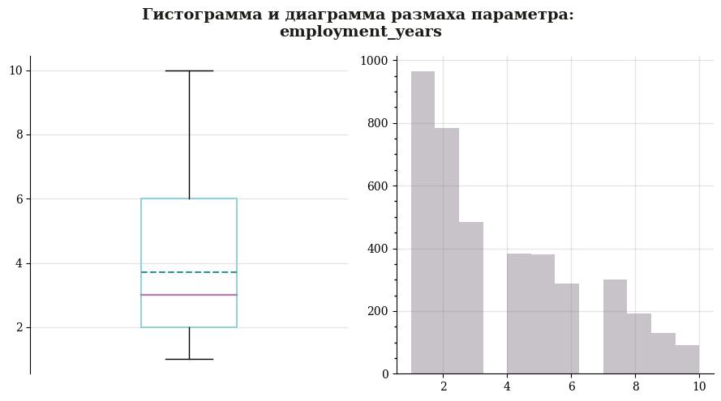

```
ShapiroResult(statistic=0.8869529962539673, pvalue=0.0)

AndersonResult(statistic=149.04931783183656, critical_values=array([0.575, 0.655, 0.786, 0.917, 1.091]), significance_level=array([15. , 10. ,  5. ,  2.5,  1. ]), fit_result=  params: FitParams(loc=3.7185, scale=2.542513292681245)
 success: True
 message: '`anderson` successfully fit the distribution to the data.')
```

```
mean     3.72
std      2.54
max     10.00
min      1.00
50%      3.00
Name: employment_years, dtype: float64
```

```
Коэффициент асимметрии: 0.73

Коэффициент эксцесса: -0.54
```

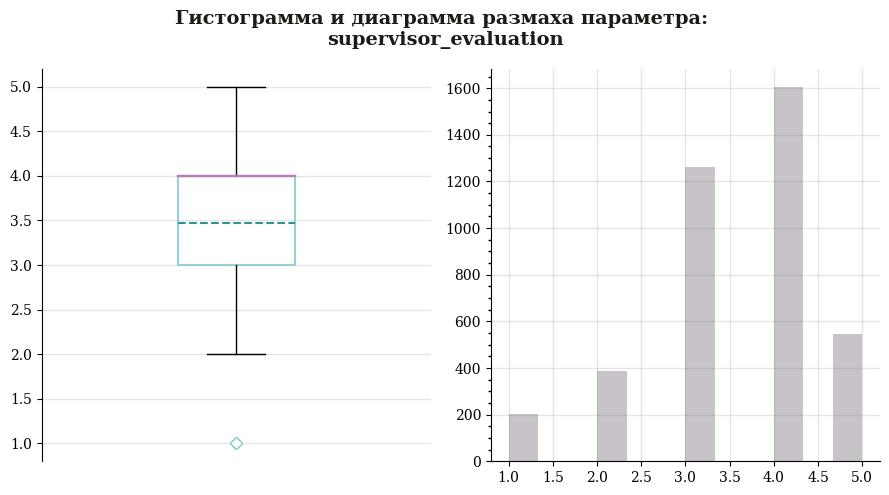

```
ShapiroResult(statistic=0.8860812187194824, pvalue=0.0)

AndersonResult(statistic=189.93269514924032, critical_values=array([0.575, 0.655, 0.786, 0.917, 1.091]), significance_level=array([15. , 10. ,  5. ,  2.5,  1. ]), fit_result=  params: FitParams(loc=3.4765, scale=1.0088122598104277)
 success: True
 message: '`anderson` successfully fit the distribution to the data.')
```

```
mean    3.48
std     1.01
max     5.00
min     1.00
50%     4.00
Name: supervisor_evaluation, dtype: float64
```

```
Коэффициент асимметрии: -0.55

Коэффициент эксцесса: 0.03
```

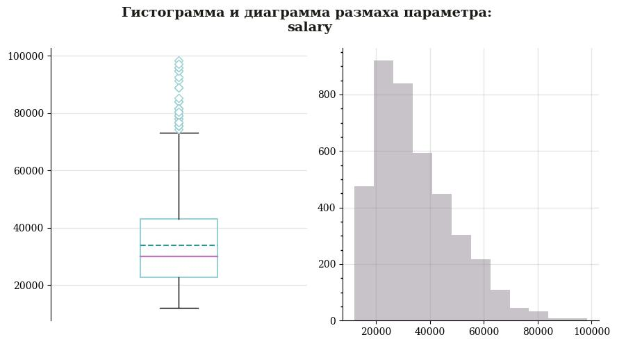

```
ShapiroResult(statistic=0.9387514591217041, pvalue=8.396205410765251e-38)

AndersonResult(statistic=66.95499922977478, critical_values=array([0.575, 0.655, 0.786, 0.917, 1.091]), significance_level=array([15. , 10. ,  5. ,  2.5,  1. ]), fit_result=  params: FitParams(loc=33926.7, scale=14900.703837528134)
 success: True
 message: '`anderson` successfully fit the distribution to the data.')
```

```
mean    33926.7
std     14900.7
max     98400.0
min     12000.0
50%     30000.0
Name: salary, dtype: float64
```

```
Коэффициент асимметрии: 0.93

Коэффициент эксцесса: 0.68
```

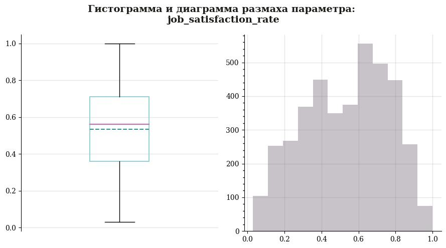

```
ShapiroResult(statistic=0.9708877801895142, pvalue=8.90544324791322e-28)

AndersonResult(statistic=34.30796045166335, critical_values=array([0.575, 0.655, 0.786, 0.917, 1.091]), significance_level=array([15. , 10. ,  5. ,  2.5,  1. ]), fit_result=  params: FitParams(loc=0.5339950000000001, scale=0.2253271689305679)
 success: True
 message: '`anderson` successfully fit the distribution to the data.')
```

```
mean    0.53
std     0.23
max     1.00
min     0.03
50%     0.56
Name: job_satisfaction_rate, dtype: float64
```

```
Коэффициент асимметрии: -0.2

Коэффициент эксцесса: -0.97
```

```python
show_distribution_graphs(train_satisfaction_df, 'train_satisfaction_df')
# вызов функции show_distribution_graphs для train_satisfaction_df
```

```
Датафрейм train_satisfaction_df:
```

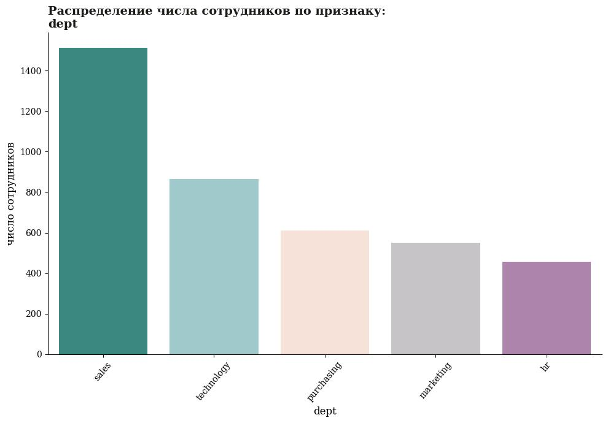

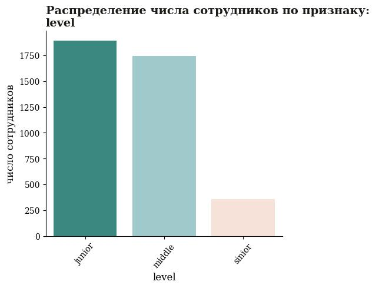

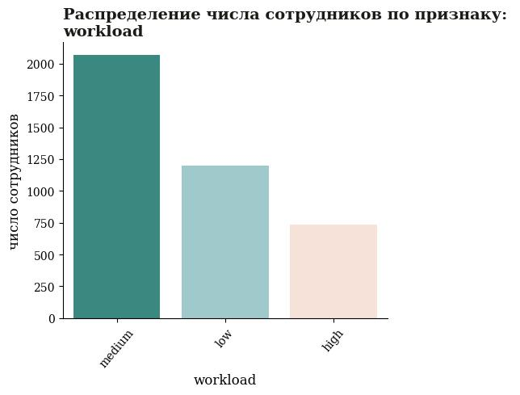

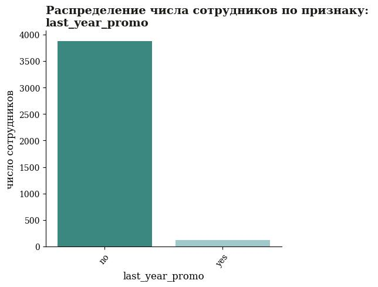

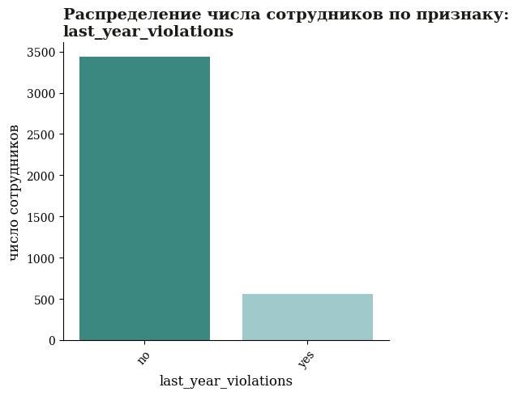

```python
show_bar_graphs(train_satisfaction_df, 'train_satisfaction_df')
# вызов функции show_bar_graphs для train_satisfaction_df
```

- **employment_years**

Медианный показатель длительности работы в компании равен **3 годам**, а стандартное отклонение - 2.5 лет. Большая часть измерений находится в промежутке *от 2 до 6 лет*. Есть часть сотрудников, проработавших в компании больше 7 лет, которые немного влияют на смещение среднего значения вверх.

- **supervisor_evaluation**

На гистограмме выделяются только **5 уникальных значений** - оценки качества работы сотрудников руководителем по шкале от 1 до 5. У 75% сотрудников оценка не превышает 4.

Распределение *не является нормальным*.

- **salary**

Средний показатель (33 926) на диаграмме размаха практически совпадает с медианным **(30 000)**, несмотря на наличие группы выбросов - сотрудников с зарплатой больше 75 000. Нам нет необходимости удалять их, это небольшой разброс зарплат. Большинство сотрудников (75%) получают зарплату меньше или равную 43 200. Стандартное отклонение переменной составляет 14 900.

Коэффициент асимметрии, стремится к 1. Распределение *нельзя назвать нормальным*. Положительный эксцесс (0.68) означает, что в данных наблюдается больше выбросов, чем в нормальном распределении.

- **job_satisfaction_rate**

Наиболее распространённый уровень удовлетворённости сотрудников работой - **0.56**. Среднее совпадает с медианой. Выбросов нет. Самая низкая оценка - 0.03.

У распределения отрицательные коэффициенты асимметрии и эксцесса. Отрицательный эксцесс (-0.97) означает, что распределение сглаженное и в данных наблюдается меньше выбросов, чем в нормальном распределении. Результат теста Андерсона-Дарлинга значим на каждом уровне значимости, а это значит, что мы *отвергаем нулевую гипотезу о нормальности распределения*.

- **dept**

Больше всего сотрудников *(38%)* работают в **отделе продаж**, на втором месте - технологический отдел. Самый малочисленный отдел - hr, там работают 11%.

- **level**

По уровню занимаемой должности разделение сотрудников кажется логичным. Основная часть - **джуны** (почти *50%*), затем по убыванию численности следуют мидлы и сеньоры. Джунов в компанию найти проще, в то же время мидлов и сеньоров приходится иногда искать месяцами.

Соотношение должностей может зависеть от степени инновационности компании. Чем сложнее и уникальнее проекты компании, которые она реализует, тем выше среди её сотрудников доля мидлов и сеньоров.

- **workload**

*Половина* сотрудников характеризуется **средним уровнем** загруженности. Низкий уровень рабочей загрузки у 1200 человек и высокий у 734.

- **last_year_promo** и **last_year_violations**

**Повышение** по результатам года получили только *3%*, в то время как **нарушение** сотрудниками трудового договора имело место в *14%* случаев.

```
Датафрейм test_features_df:
```

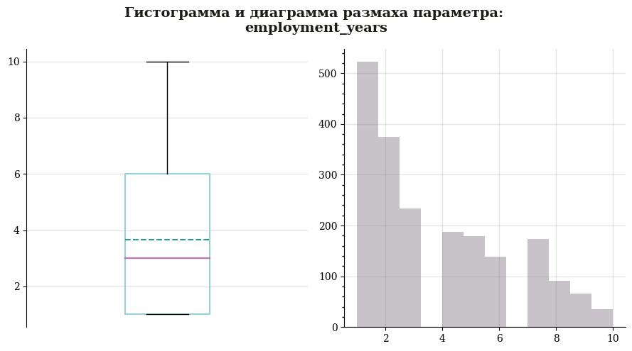

```
ShapiroResult(statistic=0.8824772834777832, pvalue=1.7712498684843336e-36)

AndersonResult(statistic=79.20333787551544, critical_values=array([0.575, 0.655, 0.785, 0.916, 1.09 ]), significance_level=array([15. , 10. ,  5. ,  2.5,  1. ]), fit_result=  params: FitParams(loc=3.6665, scale=2.5372222011974315)
 success: True
 message: '`anderson` successfully fit the distribution to the data.')
```

```
mean     3.67
std      2.54
max     10.00
min      1.00
50%      3.00
Name: employment_years, dtype: float64
```

```
Коэффициент асимметрии: 0.71

Коэффициент эксцесса: -0.62
```

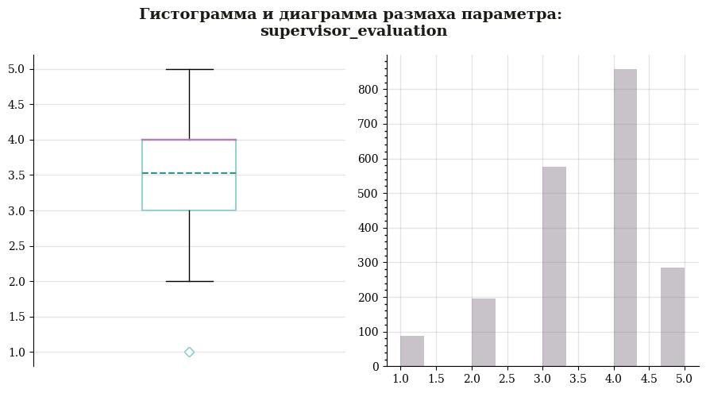

```
ShapiroResult(statistic=0.8804605007171631, pvalue=1.0240325063892793e-36)

AndersonResult(statistic=101.08786416687553, critical_values=array([0.575, 0.655, 0.785, 0.916, 1.09 ]), significance_level=array([15. , 10. ,  5. ,  2.5,  1. ]), fit_result=  params: FitParams(loc=3.5265, scale=0.9968924953693153)
 success: True
 message: '`anderson` successfully fit the distribution to the data.')
```

```
mean    3.53
std     1.00
max     5.00
min     1.00
50%     4.00
Name: supervisor_evaluation, dtype: float64
```

```
Коэффициент асимметрии: -0.61

Коэффициент эксцесса: 0.08
```

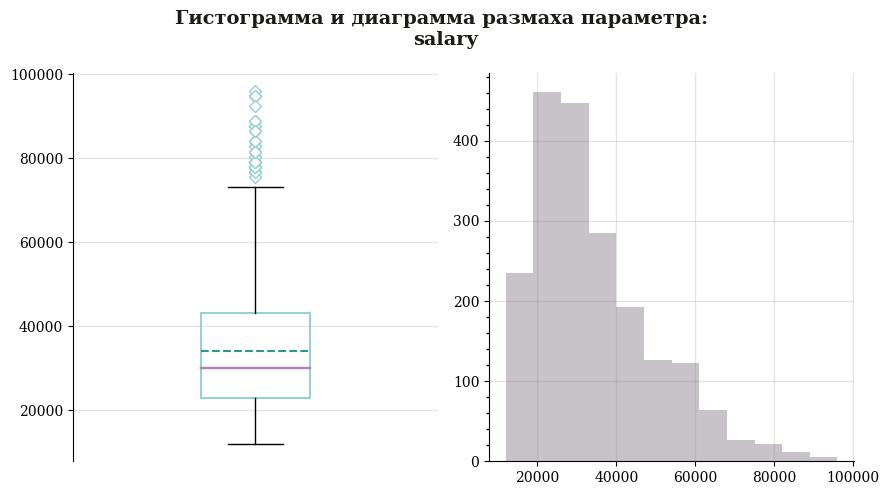

```
ShapiroResult(statistic=0.9255374073982239, pvalue=2.1315788254421244e-30)

AndersonResult(statistic=42.9954376150863, critical_values=array([0.575, 0.655, 0.785, 0.916, 1.09 ]), significance_level=array([15. , 10. ,  5. ,  2.5,  1. ]), fit_result=  params: FitParams(loc=34066.8, scale=15398.436728669487)
 success: True
 message: '`anderson` successfully fit the distribution to the data.')
```

```
mean    34066.80
std     15398.44
max     96000.00
min     12000.00
50%     30000.00
Name: salary, dtype: float64
```

```
Коэффициент асимметрии: 1.02

Коэффициент эксцесса: 0.84
```

```python
show_distribution_graphs(test_features_df, 'test_features_df')
# вызов функции show_distribution_graphs для test_features_df
```

```
Датафрейм test_features_df:
```

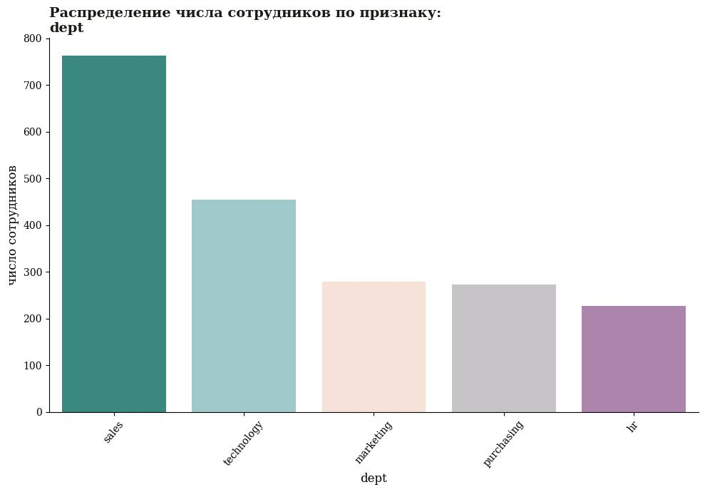

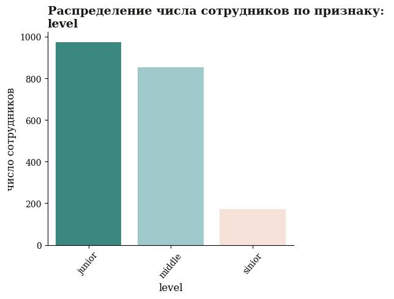

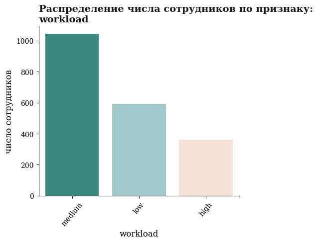

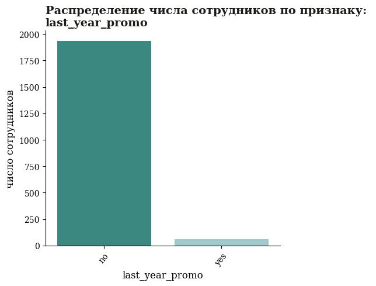

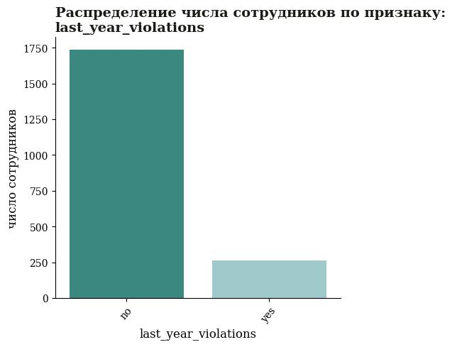

```python
show_bar_graphs(test_features_df, 'test_features_df')
# вызов функции show_bar_graphs для test_features_df
```

Распределение признаков на тренировочной и тестовой выбоках совпадает.

```
Датафрейм test_target_satisfaction_df:
```

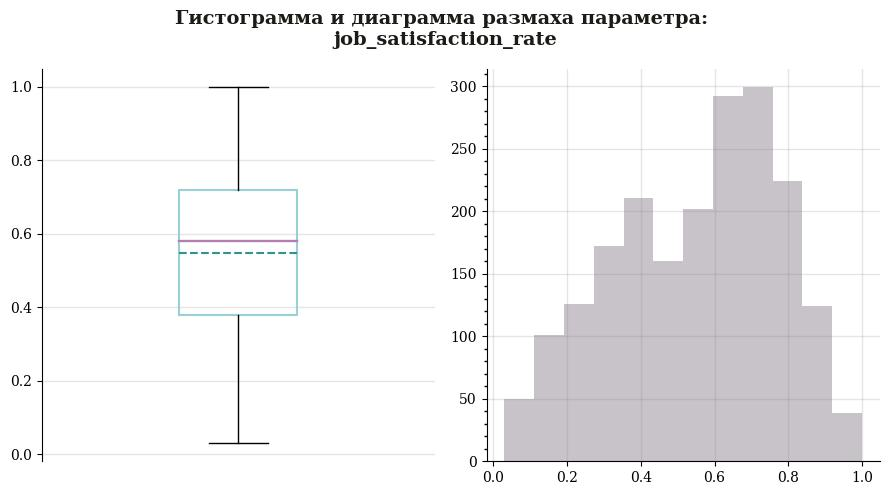

```
ShapiroResult(statistic=0.969993531703949, pvalue=5.1222639213289125e-20)

AndersonResult(statistic=19.429901966649822, critical_values=array([0.575, 0.655, 0.785, 0.916, 1.09 ]), significance_level=array([15. , 10. ,  5. ,  2.5,  1. ]), fit_result=  params: FitParams(loc=0.5487799999999999, scale=0.22010959933146693)
 success: True
 message: '`anderson` successfully fit the distribution to the data.')
```

```
mean    0.55
std     0.22
max     1.00
min     0.03
50%     0.58
Name: job_satisfaction_rate, dtype: float64
```

```
Коэффициент асимметрии: -0.31

Коэффициент эксцесса: -0.85
```

```python
show_distribution_graphs(test_target_satisfaction_df, 'test_target_satisfaction_df')
# вызов функции show_distribution_graphs для test_target_satisfaction_df
```

### Вывод:

На данном этапе мы подробно изучили распределения числовых переменных и категориальных признаков в выборке:

- определили медианные значения,
- выявили выбросы на диаграммах размаха у признаков `salary` и `supervisor_evaluation`,
- оценили нормальность распределений,
- построили столбчатые диаграммы для категориальных переменных.

## Задача 1: Корреляционный анализ

На данном этапе исследования наша задача - оценить направление и силу взаимосвязи между переменными с помощью корреляционного анализа, а также выявить мультиколлинеарность между входными признаками.

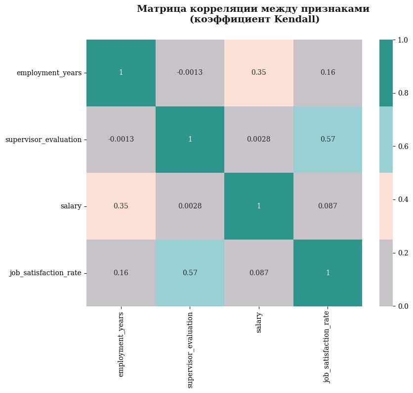

```python
fig = plt.figure(figsize=(9, 7))
fig.suptitle(f'Матрица корреляции между признаками\n (коэффициент Kendall)', fontsize=14, fontweight='demi', color='#1B1B17')
ax1 = fig.add_subplot(1, 1, 1)
sns.heatmap(train_satisfaction_df.drop('id', axis=1).corr(method='kendall'),
                                                          ax=ax1,
                                                          cmap=['#C8C3C9', '#FCE0D5', '#99D0D3', '#2E958C'],
                                                          annot=True)

plt.show()
# построение тепловой карты корреляций kendall
```

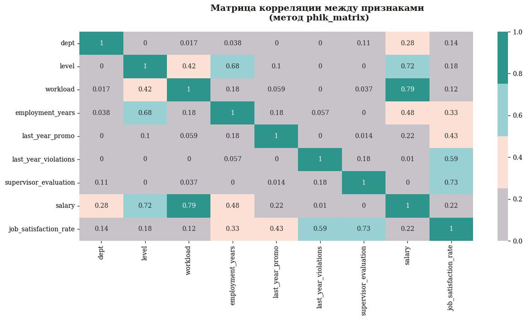

```python
fig = plt.figure(figsize=(14, 6))
fig.suptitle(f'Матрица корреляции между признаками\n (метод phik_matrix)', fontsize=14, fontweight='demi', color='#1B1B17')
ax1 = fig.add_subplot(1, 1, 1)
sns.heatmap(train_satisfaction_df.drop('id', axis=1).phik_matrix(interval_cols=['employment_years', 'supervisor_evaluation', 'salary']), ax=ax1, cmap=['#C8C3C9', '#FCE0D5', '#99D0D3', '#2E958C'], annot=True)

plt.show()
# построение тепловой карты корреляций с помощью метода phik_matrix()
```

Из всех входных признаков больше всего коррелируют между собой переменные `salary` и `workload` (коэффициент phik **0.79**), а также `salary` и `level` (коэффициент phik **0.72**). В данном случае мы не можем говорить о возможном наличии мультиколлинеарности, так как коэффициенты корреляций *меньше 0.85*.

```python
target_value_corr = (train_satisfaction_df
                     .drop('id', axis=1)
                     .phik_matrix(interval_cols=['employment_years', 'supervisor_evaluation', 'salary'])['job_satisfaction_rate']
                     .sort_values(ascending=False)
                     .to_frame()
                    )
# создание матрицы корреляций с помощью метода phik_matrix()
```

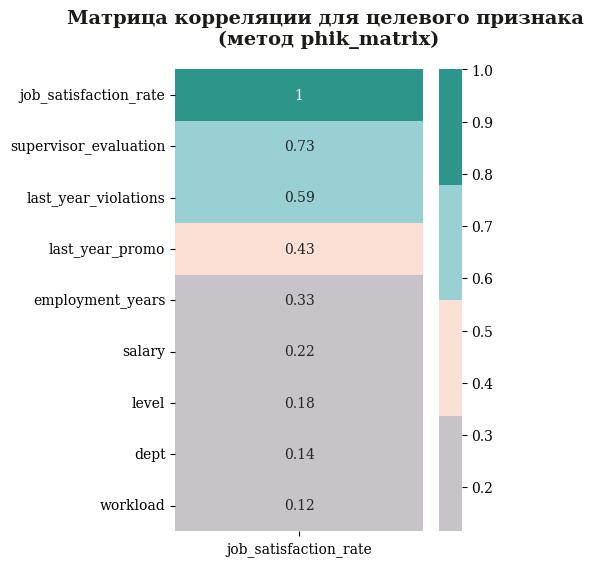

```python
fig = plt.figure(figsize=(4, 6))
fig.suptitle(f'Матрица корреляции для целевого признака\n (метод phik_matrix)', fontsize=14, fontweight='demi', color='#1B1B17')
ax1 = fig.add_subplot(1, 1, 1)
sns.heatmap(target_value_corr, ax=ax1, cmap=['#C8C3C9', '#FCE0D5', '#99D0D3', '#2E958C'], annot=True)

plt.show()
# построение тепловой карты корреляций для целевого признака
```

Целевая переменная `job_satisfaction_rate` имеет высокую корреляцию с числовым признаком `supervisor_evaluation` и среднюю с категориальным - `last_year_violations`. Коэффициенты корреляции равны **0.73** и **0.59** соответственно.

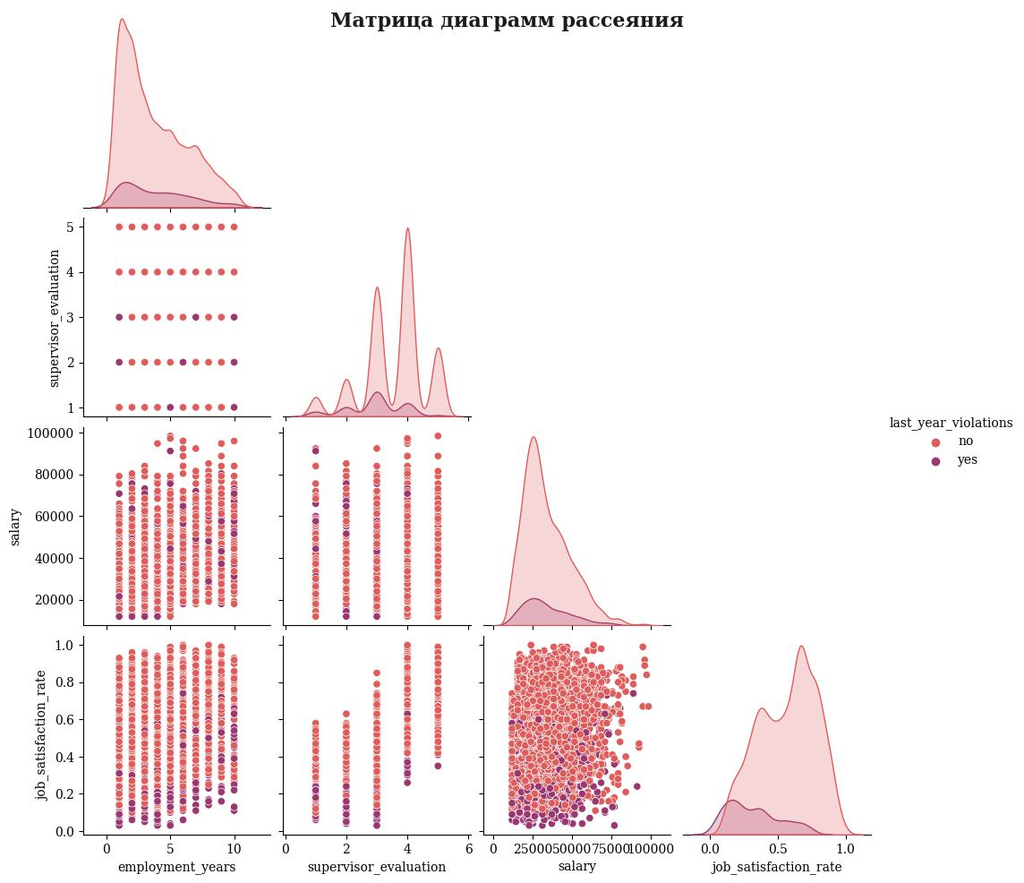

```python
g = sns.pairplot(train_satisfaction_df.drop('id', axis=1), corner=True, palette='flare', hue='last_year_violations')
g.fig.suptitle('Матрица диаграмм рассеяния', fontsize=16, fontweight='demi', color='#1B1B17')

plt.show()
# создание парных графиков: диаграмм рассеяния и гистограмм
```

### Вывод:

В первую очередь мы построили и визуализировали матрицы корреляций с коэффициентами Kendall для числовых переменных и коэффициентами phik для выявления взаимосвязей между разными типами значений (бинарными/небинарными категориальными и непрерывными числовыми). Наличие возможной мультиколлинеарности *не было выявлено*.

Целевой признак `job_satisfaction_rate` показал **высокий** коэффициент корреляции с 1 переменной: `supervisor_evaluation` - **0.73**. Средняя корреляция *(0.59)* наблюдается с признаком `last_year_violations`.

## 6. Задача 1: Подготовка данных

```python
all_test_features_df = test_features_df.merge(test_target_satisfaction_df, on='id', how='left')
# объединяем тестовые признаки с таргетом
```

Проверим, есть ли пересечения `id` сотрудников между тестовой и тренировочной выборками.

```python
len(set(all_test_features_df['id'].unique()).intersection(set(train_satisfaction_df['id'].unique())))
# определяем пересечение двух множеств
```

```
0
```

Пересечений нет, отлично.

```python
train_satisfaction_df = train_satisfaction_df.set_index('id')
all_test_features_df = all_test_features_df.set_index('id')
# переназначаем индексы
```

```python
train_satisfaction_df.columns
# наименования колонок train_satisfaction_df
```

```
Index(['dept', 'level', 'workload', 'employment_years', 'last_year_promo',
       'last_year_violations', 'supervisor_evaluation', 'salary',
       'job_satisfaction_rate'],
      dtype='object')
```

```python
num_columns = ['employment_years',
               'supervisor_evaluation',
               'salary']
ord_columns = ['level', 'workload']
ohe_columns = ['dept', 'last_year_promo', 'last_year_violations']
# создаём списки с названиями признаков
```

Признаки `employment_years`, `supervisor_evaluation`, `salary` нужно **масштабировать**, так как они относятся к типам *int* и *float*.

`level`, `workload` кодируем с помощью OrdinalEncoder, признаки имеют естественную **порядковую связь**. Напрямую укажем этот порядок в пайплайне.

Остальные признаки `dept`, `last_year_promo`, `last_year_violations` закодируем с использованием One-Hot Encoding.

```python
print(f'Количество явных дубликатов: {train_satisfaction_df.duplicated(subset=list(train_satisfaction_df.columns)).sum()} \n')
display(train_satisfaction_df[train_satisfaction_df.duplicated(subset=list(train_satisfaction_df.columns))])
# вывод строк-дубликатов
```

```
Количество явных дубликатов: 245
```

| id | dept | level | workload | employment_years | last_year_promo | last_year_violations | supervisor_evaluation | salary | job_satisfaction_rate |
| --- | --- | --- | --- | --- | --- | --- | --- | --- | --- |
| 302957 | purchasing | junior | low | 1 | no | no | 4 | 15600 | 0.61 |
| 752399 | sales | middle | low | 7 | no | no | 4 | 28800 | 0.77 |
| 802286 | sales | junior | medium | 1 | no | no | 4 | 21600 | 0.43 |
| 167303 | sales | junior | medium | 1 | no | no | 3 | 24000 | 0.34 |
| 191841 | sales | junior | medium | 1 | no | no | 5 | 21600 | 0.44 |
| ... | ... | ... | ... | ... | ... | ... | ... | ... | ... |
| 737303 | sales | middle | medium | 3 | no | no | 4 | 33600 | 0.47 |
| 281204 | technology | junior | low | 2 | no | no | 4 | 15600 | 0.68 |
| 261436 | sales | middle | low | 3 | no | no | 3 | 22800 | 0.18 |
| 457950 | technology | junior | high | 2 | no | no | 3 | 46800 | 0.45 |
| 957499 | sales | junior | medium | 2 | no | no | 4 | 21600 | 0.68 |

245 rows × 9 columns

Удалим строки-дубликаты.

```python
train_satisfaction_df_no_dupl = train_satisfaction_df.drop_duplicates()
# удаление дубликатов
```

```python
print(f'Количество явных дубликатов: {train_satisfaction_df_no_dupl.duplicated(subset=list(train_satisfaction_df.columns)).sum()} \n')
# проверка числа дубликатов
```

```
Количество явных дубликатов: 0
```

```python
X_train = train_satisfaction_df_no_dupl.drop(['job_satisfaction_rate'], axis=1)
y_train = train_satisfaction_df_no_dupl['job_satisfaction_rate']
X_test = all_test_features_df.drop(['job_satisfaction_rate'], axis=1)
y_test = all_test_features_df['job_satisfaction_rate']
# формирование X_train, y_train, X_test, y_test
```

```python
print(f'''Количество строк в тренировочной выборке: {X_train.shape[0]}
Количество признаков в тренировочной выборке: {X_train.shape[1]}''')
```

```
Количество строк в тренировочной выборке: 3755
Количество признаков в тренировочной выборке: 8
```

```python
print(f'''Количество строк в тестовой выборке: {X_test.shape[0]}
Количество признаков в тестовой выборке: {X_test.shape[1]}''')
```

```
Количество строк в тестовой выборке: 2000
Количество признаков в тестовой выборке: 8
```

## 7. Задача 1: Обучение моделей

```python
ohe_pipe = Pipeline(
    [('simpleImputer_ohe', SimpleImputer(missing_values=np.nan, strategy='most_frequent')),
     ('ohe', OneHotEncoder(drop='first', handle_unknown='ignore'))
    ]
    )
# создаём пайплайн для подготовки признаков из списка ohe_columns: заполнение пропусков и OHE-кодирование
# SimpleImputer + OHE

ord_pipe = Pipeline(
    [('simpleImputer_before_ord', SimpleImputer(missing_values=np.nan, strategy='most_frequent')),
     ('ord',  OrdinalEncoder(categories=[['junior', 'middle', 'sinior'],
                                         ['low', 'medium', 'high']],
                             handle_unknown='use_encoded_value',
                             unknown_value=np.nan
                            )
        ),
     ('simpleImputer_after_ord', SimpleImputer(missing_values=np.nan, strategy='most_frequent'))
    ]
)
# создаём пайплайн для подготовки признаков из списка ord_columns: заполнение пропусков и Ordinal-кодирование
# SimpleImputer + OE

data_preprocessor = ColumnTransformer(
    [('ohe', ohe_pipe, ohe_columns),
     ('ord', ord_pipe, ord_columns),
     ('num', StandardScaler(), num_columns)
    ],
    remainder='passthrough'
)
# создаём общий пайплайн для подготовки данных - кодирования и масштабирования
```

```python
pipe_final = Pipeline([
    ('preprocessor', data_preprocessor),
    ('models', LinearRegression())
])
# создаём итоговый пайплайн: подготовка данных и модель

param_grid = [
    {
        'models': [DecisionTreeRegressor(random_state=RANDOM_STATE)],
        'models__max_depth': range(2, 20),
        'models__max_features': range(2, 20),
        'preprocessor__num': [StandardScaler(), MinMaxScaler(), RobustScaler(), 'passthrough']
    },
    # словарь для модели DecisionTreeClassifier()

    {
        'models': [LinearRegression()],
        'preprocessor__num': [StandardScaler(), MinMaxScaler(), RobustScaler(), 'passthrough']
    }
    # словарь для модели LinearRegression()
]
```

Создадим новую метрику — **SMAPE** (англ. symmetric mean absolute percentage error, «симметричное среднее абсолютное процентное отклонение») для оценки качества моделей при переборе гиперпараметров.

```python
def smape_count(y_true, y_pred):
    error = np.abs(y_true - y_pred)
    scale = (np.abs(y_true) + np.abs(y_pred)) / 2
    smape = np.mean(error / scale) * 100
    return smape
# создание фунции подсчёта SMAPE
```

```python
smape_scorer = make_scorer(score_func=smape_count, greater_is_better=False)
```

```python
randomized_search = RandomizedSearchCV(
    pipe_final,
    param_grid,
    cv=5,
    scoring=smape_scorer,
    random_state=RANDOM_STATE,
    n_jobs=-1
)
# запуск поиска гиперпараметров с помощью GridSearchCV

randomized_search.fit(X_train, y_train)
# обучение модели

print('Лучшая модель и её параметры:\n\n', randomized_search.best_estimator_)
print('Метрика SMAPE лучшей модели на кросс валидационной выборке:', round(randomized_search.best_score_ * (-1), 3))
```

```
Лучшая модель и её параметры:

 Pipeline(steps=[('preprocessor',
                 ColumnTransformer(remainder='passthrough',
                                   transformers=[('ohe',
                                                  Pipeline(steps=[('simpleImputer_ohe',
                                                                   SimpleImputer(strategy='most_frequent')),
                                                                  ('ohe',
                                                                   OneHotEncoder(drop='first',
                                                                                 handle_unknown='ignore'))]),
                                                  ['dept', 'last_year_promo',
                                                   'last_year_violations']),
                                                 ('ord',
                                                  Pipeline(steps=[('simpleImputer_before_ord',
                                                                   SimpleImputer...
                                                                                               'middle',
                                                                                               'sinior'],
                                                                                              ['low',
                                                                                               'medium',
                                                                                               'high']],
                                                                                  handle_unknown='use_encoded_value',
                                                                                  unknown_value=nan)),
                                                                  ('simpleImputer_after_ord',
                                                                   SimpleImputer(strategy='most_frequent'))]),
                                                  ['level', 'workload']),
                                                 ('num', StandardScaler(),
                                                  ['employment_years',
                                                   'supervisor_evaluation',
                                                   'salary'])])),
                ('models',
                 DecisionTreeRegressor(max_depth=13, max_features=19,
                                       random_state=42))])
Метрика SMAPE лучшей модели на кросс валидационной выборке: 15.768
```

```python
y_pred = randomized_search.best_estimator_.predict(X_test)
print('Метрика SMAPE лучшей модели на тестовой выборке:', round(smape_count(y_test, y_pred), 3))
```

```
Метрика SMAPE лучшей модели на тестовой выборке: 14.383
```

```python
best_model = randomized_search.best_estimator_
# сохраняем лучшую модель
```

### Вывод:

Лучшей моделью для предсказания уровня удовлетворённости сотрудников оказалась модель **"Дерево решений" - DecisionTreeRegressor(max_depth=13, max_features=19, random_state=42)**. Метрика *SMAPE* качества для кросс валидационной выборки - **15.768**. На тестовых данных - **14.383**. Это соответсвует критерию успеха для тестовых данных: *SMAPE <= 15*.

## Задача 2: Обзор, предобработка данных

```python
get_df_info(test_features_df)
# вызов функции get_df_info для test_features_df
```

|  | id | dept | level | workload | employment_years | last_year_promo | last_year_violations | supervisor_evaluation | salary |
| --- | --- | --- | --- | --- | --- | --- | --- | --- | --- |
| 0 | 485046 | marketing | junior | medium | 2 | no | no | 5 | 28800 |
| 1 | 686555 | hr | junior | medium | 1 | no | no | 4 | 30000 |
| 2 | 467458 | sales | middle | low | 5 | no | no | 4 | 19200 |
| 3 | 418655 | sales | middle | low | 6 | no | no | 4 | 19200 |
| 4 | 789145 | hr | middle | medium | 5 | no | no | 5 | 40800 |
| 5 | 429973 | purchasing | middle | medium | 6 | no | no | 3 | 42000 |
| 6 | 850699 | technology | junior | medium | 3 | no | no | 3 | 26400 |
| 7 | 500791 | sales | middle | high | 9 | no | no | 4 | 49200 |
| 8 | 767867 | marketing | middle | high | 3 | no | yes | 4 | 62400 |
| 9 | 937235 | sales | junior | medium | 1 | no | yes | 3 | 26400 |

```
<class 'pandas.core.frame.DataFrame'>
RangeIndex: 2000 entries, 0 to 1999
Data columns (total 9 columns):
 #   Column                 Non-Null Count  Dtype
---  ------                 --------------  -----
 0   id                     2000 non-null   int64
 1   dept                   1997 non-null   object
 2   level                  1999 non-null   object
 3   workload               1999 non-null   object
 4   employment_years       2000 non-null   int64
 5   last_year_promo        2000 non-null   object
 6   last_year_violations   2000 non-null   object
 7   supervisor_evaluation  2000 non-null   int64
 8   salary                 2000 non-null   int64
dtypes: int64(4), object(5)
memory usage: 140.8+ KB
```

```
None
```

|  | id | dept | level | workload | employment_years | last_year_promo | last_year_violations | supervisor_evaluation | salary |
| --- | --- | --- | --- | --- | --- | --- | --- | --- | --- |
| count | 2000.000000 | 1997 | 1999 | 1999 | 2000.000000 | 2000 | 2000 | 2000.000000 | 2000.000000 |
| unique | NaN | 5 | 3 | 3 | NaN | 2 | 2 | NaN | NaN |
| top | NaN | sales | junior | medium | NaN | no | no | NaN | NaN |
| freq | NaN | 763 | 974 | 1043 | NaN | 1937 | 1738 | NaN | NaN |
| mean | 552765.213500 | NaN | NaN | NaN | 3.666500 | NaN | NaN | 3.526500 | 34066.800000 |
| std | 253851.326129 | NaN | NaN | NaN | 2.537222 | NaN | NaN | 0.996892 | 15398.436729 |
| min | 100298.000000 | NaN | NaN | NaN | 1.000000 | NaN | NaN | 1.000000 | 12000.000000 |
| 25% | 339052.000000 | NaN | NaN | NaN | 1.000000 | NaN | NaN | 3.000000 | 22800.000000 |
| 50% | 550793.000000 | NaN | NaN | NaN | 3.000000 | NaN | NaN | 4.000000 | 30000.000000 |
| 75% | 765763.750000 | NaN | NaN | NaN | 6.000000 | NaN | NaN | 4.000000 | 43200.000000 |
| max | 999029.000000 | NaN | NaN | NaN | 10.000000 | NaN | NaN | 5.000000 | 96000.000000 |

```
Index(['id', 'dept', 'level', 'workload', 'employment_years',
       'last_year_promo', 'last_year_violations', 'supervisor_evaluation',
       'salary'],
      dtype='object')
```

```python
get_df_info(train_quit_df)
# вызов функции get_df_info для train_quit_df
```

|  | id | dept | level | workload | employment_years | last_year_promo | last_year_violations | supervisor_evaluation | salary | quit |
| --- | --- | --- | --- | --- | --- | --- | --- | --- | --- | --- |
| 0 | 723290 | sales | middle | high | 2 | no | no | 4 | 54000 | no |
| 1 | 814010 | sales | junior | medium | 2 | no | no | 4 | 27600 | no |
| 2 | 155091 | purchasing | middle | medium | 5 | no | no | 1 | 37200 | no |
| 3 | 257132 | sales | junior | medium | 2 | no | yes | 3 | 24000 | yes |
| 4 | 910140 | marketing | junior | medium | 2 | no | no | 5 | 25200 | no |
| 5 | 699916 | sales | junior | low | 1 | no | yes | 3 | 18000 | yes |
| 6 | 417070 | technology | middle | medium | 8 | no | no | 2 | 44400 | no |
| 7 | 165489 | sales | middle | low | 4 | no | no | 5 | 19200 | no |
| 8 | 996399 | marketing | middle | low | 7 | no | no | 4 | 25200 | no |
| 9 | 613206 | technology | middle | medium | 2 | no | no | 3 | 45600 | yes |

```
<class 'pandas.core.frame.DataFrame'>
RangeIndex: 4000 entries, 0 to 3999
Data columns (total 10 columns):
 #   Column                 Non-Null Count  Dtype
---  ------                 --------------  -----
 0   id                     4000 non-null   int64
 1   dept                   4000 non-null   object
 2   level                  4000 non-null   object
 3   workload               4000 non-null   object
 4   employment_years       4000 non-null   int64
 5   last_year_promo        4000 non-null   object
 6   last_year_violations   4000 non-null   object
 7   supervisor_evaluation  4000 non-null   int64
 8   salary                 4000 non-null   int64
 9   quit                   4000 non-null   object
dtypes: int64(4), object(6)
memory usage: 312.6+ KB
```

```
None
```

|  | id | dept | level | workload | employment_years | last_year_promo | last_year_violations | supervisor_evaluation | salary | quit |
| --- | --- | --- | --- | --- | --- | --- | --- | --- | --- | --- |
| count | 4000.000000 | 4000 | 4000 | 4000 | 4000.000000 | 4000 | 4000 | 4000.000000 | 4000.000000 | 4000 |
| unique | NaN | 5 | 3 | 3 | NaN | 2 | 2 | NaN | NaN | 2 |
| top | NaN | sales | junior | medium | NaN | no | no | NaN | NaN | no |
| freq | NaN | 1438 | 1949 | 2118 | NaN | 3887 | 3455 | NaN | NaN | 2872 |
| mean | 552099.283750 | NaN | NaN | NaN | 3.701500 | NaN | NaN | 3.474750 | 33805.800000 | NaN |
| std | 260158.031387 | NaN | NaN | NaN | 2.541852 | NaN | NaN | 1.004049 | 15152.415163 | NaN |
| min | 100222.000000 | NaN | NaN | NaN | 1.000000 | NaN | NaN | 1.000000 | 12000.000000 | NaN |
| 25% | 327785.750000 | NaN | NaN | NaN | 2.000000 | NaN | NaN | 3.000000 | 22800.000000 | NaN |
| 50% | 546673.000000 | NaN | NaN | NaN | 3.000000 | NaN | NaN | 4.000000 | 30000.000000 | NaN |
| 75% | 781497.750000 | NaN | NaN | NaN | 6.000000 | NaN | NaN | 4.000000 | 43200.000000 | NaN |
| max | 999915.000000 | NaN | NaN | NaN | 10.000000 | NaN | NaN | 5.000000 | 96000.000000 | NaN |

```
Index(['id', 'dept', 'level', 'workload', 'employment_years',
       'last_year_promo', 'last_year_violations', 'supervisor_evaluation',
       'salary', 'quit'],
      dtype='object')
```

```python
get_df_info(test_target_quit_df)
# вызов функции get_df_info для test_target_quit_df
```

|  | id | quit |
| --- | --- | --- |
| 0 | 999029 | yes |
| 1 | 372846 | no |
| 2 | 726767 | no |
| 3 | 490105 | no |
| 4 | 416898 | yes |
| 5 | 223063 | no |
| 6 | 810370 | no |
| 7 | 998900 | no |
| 8 | 578329 | no |
| 9 | 648850 | no |

```
<class 'pandas.core.frame.DataFrame'>
RangeIndex: 2000 entries, 0 to 1999
Data columns (total 2 columns):
 #   Column  Non-Null Count  Dtype
---  ------  --------------  -----
 0   id      2000 non-null   int64
 1   quit    2000 non-null   object
dtypes: int64(1), object(1)
memory usage: 31.4+ KB
```

```
None
```

|  | id | quit |
| --- | --- | --- |
| count | 2000.000000 | 2000 |
| unique | NaN | 2 |
| top | NaN | no |
| freq | NaN | 1436 |
| mean | 552765.213500 | NaN |
| std | 253851.326129 | NaN |
| min | 100298.000000 | NaN |
| 25% | 339052.000000 | NaN |
| 50% | 550793.000000 | NaN |
| 75% | 765763.750000 | NaN |
| max | 999029.000000 | NaN |

```
Index(['id', 'quit'], dtype='object')
```

```python
data_overview(test_features_df, 'test_features_df')
# вызов функции data_overview() для test_features_df
```

```
Таблица test_features_df

Названия столбцов:

['id' 'dept' 'level' 'workload' 'employment_years' 'last_year_promo'
 'last_year_violations' 'supervisor_evaluation' 'salary']

Количество явных дубликатов: 0
```

|  | id | dept | level | workload | employment_years | last_year_promo | last_year_violations | supervisor_evaluation | salary |
| --- | --- | --- | --- | --- | --- | --- | --- | --- | --- |

```
Число уникальных совпадений в столбце dept:
```

```
sales         763
technology    455
marketing     279
purchasing    273
hr            227
Name: dept, dtype: int64
```

```
Число уникальных совпадений в столбце level:
```

```
junior    974
middle    854
sinior    171
Name: level, dtype: int64
```

```
Число уникальных совпадений в столбце workload:
```

```
medium    1043
low        593
high       363
Name: workload, dtype: int64
```

```
Число уникальных совпадений в столбце last_year_promo:
```

```
no     1937
yes      63
Name: last_year_promo, dtype: int64
```

```
Число уникальных совпадений в столбце last_year_violations:
```

```
no     1738
yes     262
Name: last_year_violations, dtype: int64
```

```
Количество пропусков в датафрейме test_features_df:

id                       0
dept                     3
level                    1
workload                 1
employment_years         0
last_year_promo          0
last_year_violations     0
supervisor_evaluation    0
salary                   0
dtype: int64

Типы данных по столбцам в test_features_df:

id                        int64
dept                     object
level                    object
workload                 object
employment_years          int64
last_year_promo          object
last_year_violations     object
supervisor_evaluation     int64
salary                    int64
dtype: object
```

```python
test_features_df[(test_features_df['dept'].isna()) | (test_features_df['level'].isna()) | (test_features_df['workload'].isna())]
# срез данных
```

|  | id | dept | level | workload | employment_years | last_year_promo | last_year_violations | supervisor_evaluation | salary |
| --- | --- | --- | --- | --- | --- | --- | --- | --- | --- |
| 15 | 590867 | marketing | junior | NaN | 4 | no | no | 4 | 28800 |
| 191 | 609865 | NaN | junior | medium | 1 | no | no | 1 | 20400 |
| 312 | 471990 | sales | NaN | low | 1 | no | no | 3 | 12000 |
| 1196 | 832342 | NaN | junior | medium | 1 | no | no | 4 | 28800 |
| 1699 | 822186 | NaN | middle | medium | 3 | no | no | 4 | 38400 |

Есть пропуски в категориях `dept`, `workload` и `level`. Так как пропущенных значений мало, мы можем не тратить время на их заполнение сейчас. Автоматически в пайплайне (data_preprocessor) заменим их на самое распространённое значение по выборке с использованием SimpleImputer.

Явных дубликатов в таблице не обнаружилось. Дополнительно проверим датафрейм на наличие строк-дубликатов без учёта уникального id сотрудников.

```python
print(f'Количество строк-дубликатов: {test_features_df.duplicated(subset=list(test_features_df.columns)[1:]).sum()}')
print('Доля строк-дубликатов: {:.2%}'.format(test_features_df.duplicated(subset=list(test_features_df.columns)[1:]).sum() / test_features_df.shape[0]))
# подсчёт строк-дубликатов
```

```
Количество строк-дубликатов: 557
Доля строк-дубликатов: 27.85%
```

Есть дубликаты с характеристиками сотрудников. В таблице много категориальных признаков, поэтому некоторые из них могут повторяться. Эти данные нам предоставила сама компания и у нас нет оснований не доверять им. Для тестовой выборки наличие таких дубликатов не критично.

```python
data_overview(train_quit_df, 'train_quit_df')
# вызов функции data_overview() для test_features_df
```

```
Таблица train_quit_df

Названия столбцов:

['id' 'dept' 'level' 'workload' 'employment_years' 'last_year_promo'
 'last_year_violations' 'supervisor_evaluation' 'salary' 'quit']

Количество явных дубликатов: 0
```

|  | id | dept | level | workload | employment_years | last_year_promo | last_year_violations | supervisor_evaluation | salary | quit |
| --- | --- | --- | --- | --- | --- | --- | --- | --- | --- | --- |

```
Число уникальных совпадений в столбце dept:
```

```
sales         1438
technology     928
purchasing     588
marketing      582
hr             464
Name: dept, dtype: int64
```

```
Число уникальных совпадений в столбце level:
```

```
junior    1949
middle    1694
sinior     357
Name: level, dtype: int64
```

```
Число уникальных совпадений в столбце workload:
```

```
medium    2118
low       1208
high       674
Name: workload, dtype: int64
```

```
Число уникальных совпадений в столбце last_year_promo:
```

```
no     3887
yes     113
Name: last_year_promo, dtype: int64
```

```
Число уникальных совпадений в столбце last_year_violations:
```

```
no     3455
yes     545
Name: last_year_violations, dtype: int64
```

```
Число уникальных совпадений в столбце quit:
```

```
no     2872
yes    1128
Name: quit, dtype: int64
```

```
Количество пропусков в датафрейме train_quit_df:

id                       0
dept                     0
level                    0
workload                 0
employment_years         0
last_year_promo          0
last_year_violations     0
supervisor_evaluation    0
salary                   0
quit                     0
dtype: int64

Типы данных по столбцам в train_quit_df:

id                        int64
dept                     object
level                    object
workload                 object
employment_years          int64
last_year_promo          object
last_year_violations     object
supervisor_evaluation     int64
salary                    int64
quit                     object
dtype: object
```

```python
print(f'Количество строк с пропусками: {train_quit_df.isna().sum().sum()}')
print('Доля строк с пропусками: {:.2%}'.format(train_quit_df.isna().sum().sum() / train_quit_df.shape[0]))
# подсчёт строк-дубликатов
```

```
Количество строк с пропусками: 0
Доля строк с пропусками: 0.00%
```

Также посмотрим, сколько строк-дубликатов без учёта уникального id сотрудников присутствует в таблице train_quit_df.

```python
print(f'Количество строк-дубликатов: {train_quit_df.duplicated(subset=list(train_quit_df.columns)[1:]).sum()}')
print('Доля строк-дубликатов: {:.2%}'.format(train_quit_df.duplicated(subset=list(train_quit_df.columns)[1:]).sum() / train_quit_df.shape[0]))
# подсчёт строк-дубликатов
```

```
Количество строк-дубликатов: 1413
Доля строк-дубликатов: 35.33%
```

В данном случае дубликаты могут повлиять на процесс обучения модели и в конце есть вероятность получить искажённые результаты. На этапе подготовки данных придётся удалить эти строки.

```python
data_overview(test_target_quit_df, 'test_target_quit_df')
# вызов функции data_overview() для test_features_df
```

```
Таблица test_target_quit_df

Названия столбцов:

['id' 'quit']

Количество явных дубликатов: 0
```

|  | id | quit |
| --- | --- | --- |

```
Число уникальных совпадений в столбце quit:
```

```
no     1436
yes     564
Name: quit, dtype: int64
```

```
Количество пропусков в датафрейме test_target_quit_df:

id      0
quit    0
dtype: int64

Типы данных по столбцам в test_target_quit_df:

id       int64
quit    object
dtype: object
```

### Вывод:

Датафрейм test_features_df содержит тестовые данные с **характеристиками** сотрудников:

- `id` — уникальный идентификатор сотрудника;
- `dept` — отдел, в котором работает сотрудник;
- `level` — уровень занимаемой должности;
- `workload` — уровень загруженности сотрудника;
- `employment_years` — длительность работы в компании (в годах);
- `last_year_promo` — показывает, было ли повышение за последний год;
- `last_year_violations` — показывает, нарушал ли сотрудник трудовой договор за последний год;
- `supervisor_evaluation` — оценка качества работы сотрудника, которую дал руководитель;
- `salary` — ежемесячная зарплата сотрудника.

Датафрейм test_target_quit_df - это данные по второму целевому признаку для тестовой выборки - `quit` (увольнение сотрудника из компании).

train_quit_df - тренировочная выборка.

Все датафреймы связаны между собой столбцом с `id` сотрудников.

Явных полных дубликатов в таблицах не нашлось. Все типы данных соответствуют значениям в столбцах.

Мы обнаружили пропуски и пробелы в категориальных столбцах `dept`, `workload`, `level` датафрейма test_features_df. Все пропуски мы решили заменить в пайплайне на самое распространённое значение по категориям.

В датафреймах train_quit_df и test_target_quit_df пропусков не обнаружено.

Нашлись дубликаты с характеристиками сотрудников без учёта уникальных id. Далее мы удалим их из тренировочной выборки train_quit_df, чтобы они не повлияли на процесс обучения моделей.

## Задача 2: Исследовательский анализ данных

```
Датафрейм train_quit_df:
```

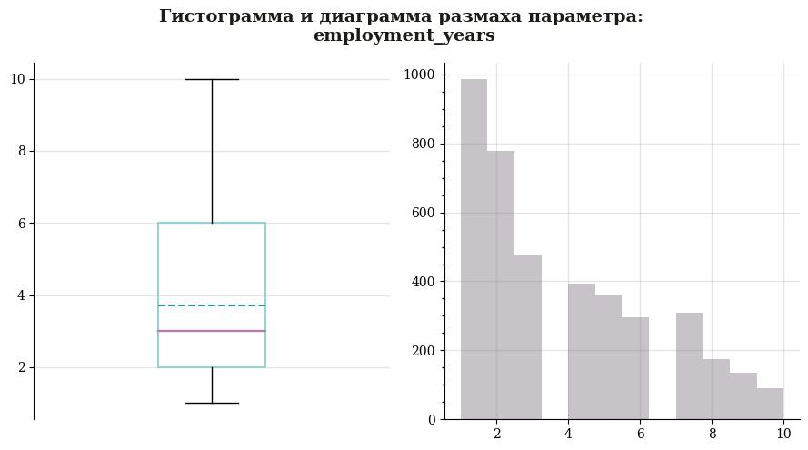

```
ShapiroResult(statistic=0.8856356143951416, pvalue=0.0)

AndersonResult(statistic=150.79175720118565, critical_values=array([0.575, 0.655, 0.786, 0.917, 1.091]), significance_level=array([15. , 10. ,  5. ,  2.5,  1. ]), fit_result=  params: FitParams(loc=3.7015, scale=2.5418522780151473)
 success: True
 message: '`anderson` successfully fit the distribution to the data.')
```

```
mean     3.70
std      2.54
max     10.00
min      1.00
50%      3.00
Name: employment_years, dtype: float64
```

```
Коэффициент асимметрии: 0.74

Коэффициент эксцесса: -0.52
```

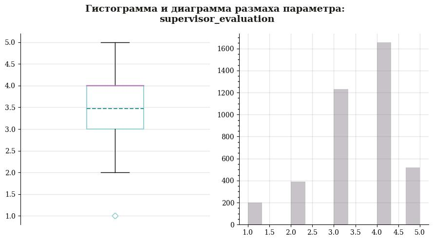

```
ShapiroResult(statistic=0.8830316066741943, pvalue=0.0)

AndersonResult(statistic=197.35187959952782, critical_values=array([0.575, 0.655, 0.786, 0.917, 1.091]), significance_level=array([15. , 10. ,  5. ,  2.5,  1. ]), fit_result=  params: FitParams(loc=3.47475, scale=1.0040490357131562)
 success: True
 message: '`anderson` successfully fit the distribution to the data.')
```

```
mean    3.47
std     1.00
max     5.00
min     1.00
50%     4.00
Name: supervisor_evaluation, dtype: float64
```

```
Коэффициент асимметрии: -0.58

Коэффициент эксцесса: 0.06
```

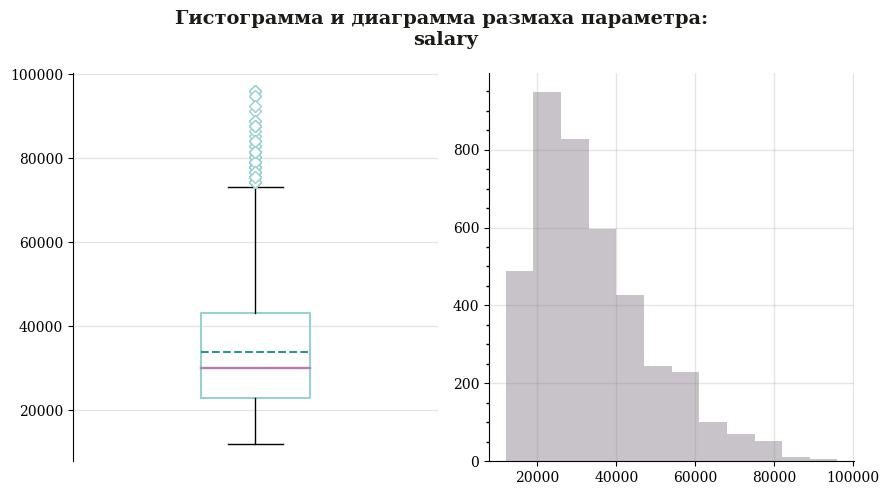

```
ShapiroResult(statistic=0.9303956627845764, pvalue=1.0890064898638527e-39)

AndersonResult(statistic=78.03346608697211, critical_values=array([0.575, 0.655, 0.786, 0.917, 1.091]), significance_level=array([15. , 10. ,  5. ,  2.5,  1. ]), fit_result=  params: FitParams(loc=33805.8, scale=15152.415163310858)
 success: True
 message: '`anderson` successfully fit the distribution to the data.')
```

```
mean    33805.80
std     15152.42
max     96000.00
min     12000.00
50%     30000.00
Name: salary, dtype: float64
```

```
Коэффициент асимметрии: 0.99

Коэффициент эксцесса: 0.74
```

```python
show_distribution_graphs(train_quit_df, 'train_quit_df')
# вызов функции show_distribution_graphs для train_quit_df
```

```
Датафрейм train_quit_df:
```

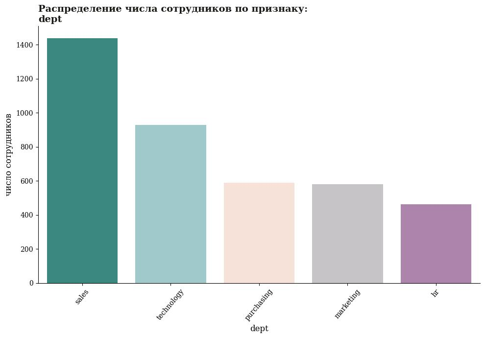

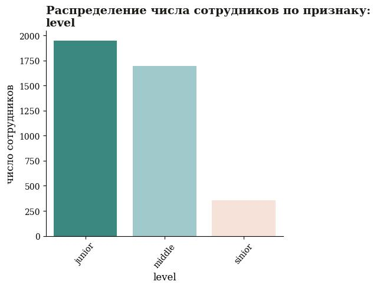

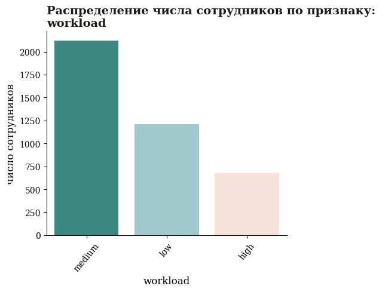

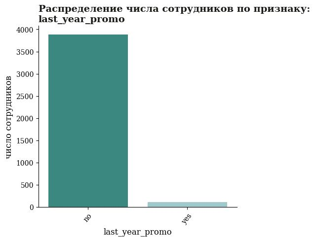

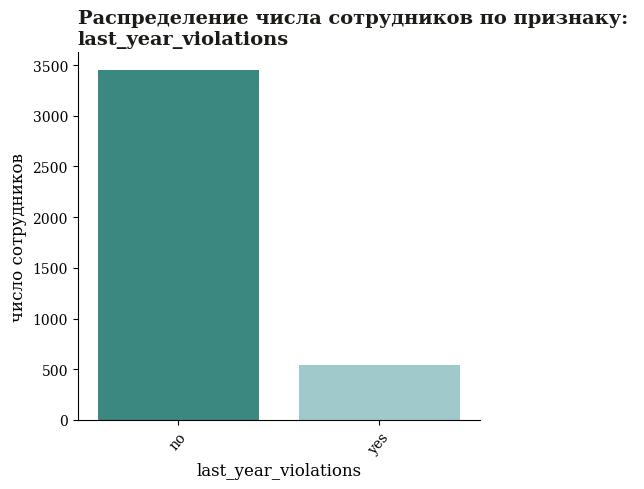

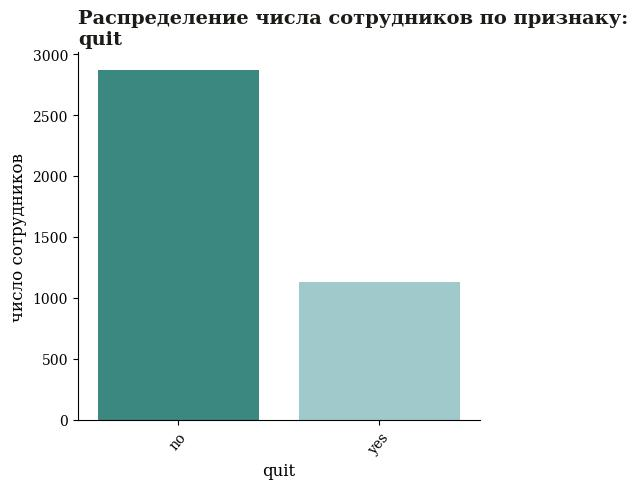

```python
show_bar_graphs(train_quit_df, 'train_quit_df')
# вызов функции show_bar_graphs для train_quit_df
```